# Part I - Airline On-Time Performance Data Exploration

## by Corinne Sandor

- Introduction
- Preliminary Wrangling
- Data Wrangling
- Finalized Dataframe
- Univariate Exploration
- Bivariate Exploration
- Multivariate Exploration
- Conclusions

## Introduction

This document explores a dataset containing airline on-time preformance from about 2.5 million flights spanning from 1987 to 2008 (with the exception of the years 2001 & 2002).

## Preliminary Wrangling

```python
# import all packages and set plots to be embedded inline
import numpy as np
import pandas as pd
import matplotlib.pyplot as plt
import seaborn as sb
import datetime

%matplotlib inline
```

```python
df = pd.read_csv('merged_data.csv',
                 dtype = {'Year': int, 'Month': int, 'DayofMonth': int,
                         'DayofWeek': float, 'DepTime': float, 'CRSDepTime': float,
                         'ArrTime': float, 'CRSArrTime':float, 'UniqueCarrier': str,
                         'FlightNum':float, 'TailNum':str, 'ActualElapsedTime':float,
                         'CRSElapsedTime':float, 'AirTime': float, 'ArrDelay': float,
                         'DepDelay': float, 'Origin': str, 'Dest': str, 'Distance': float,
                         'TaxiIn': float, 'TaxiOut': float, 'Cancelled': float,
                         'CancellationCode': str, 'Diverted': float,
                         'CarrierDelay': float, 'WeatherDelay': str, 'NASDelay': str,
                         'SecurityDelay':float, 'LateAircraftDelay': float})
```

```python
df.head()
```

|  | Unnamed: 0 | Year | Month | DayofMonth | DayOfWeek | DepTime | CRSDepTime | ArrTime | CRSArrTime | UniqueCarrier | ... | TaxiIn | TaxiOut | Cancelled | CancellationCode | Diverted | CarrierDelay | WeatherDelay | NASDelay | SecurityDelay | LateAircraftDelay |
| --- | --- | --- | --- | --- | --- | --- | --- | --- | --- | --- | --- | --- | --- | --- | --- | --- | --- | --- | --- | --- | --- |
| 0 | 0 | 1999 | 1 | 27 | 3.0 | 1906.0 | 1908.0 | 2024.0 | 2005.0 | US | ... | 3.0 | 9.0 | 0.0 | NaN | 0.0 | NaN | NaN | NaN | NaN | NaN |
| 1 | 1 | 1999 | 1 | 28 | 4.0 | 2016.0 | 1908.0 | 2126.0 | 2005.0 | US | ... | 19.0 | 10.0 | 0.0 | NaN | 0.0 | NaN | NaN | NaN | NaN | NaN |
| 2 | 2 | 1999 | 1 | 29 | 5.0 | 1907.0 | 1908.0 | 2000.0 | 2005.0 | US | ... | 2.0 | 8.0 | 0.0 | NaN | 0.0 | NaN | NaN | NaN | NaN | NaN |
| 3 | 3 | 1999 | 1 | 31 | 7.0 | 1932.0 | 1908.0 | 2031.0 | 2005.0 | US | ... | 6.0 | 8.0 | 0.0 | NaN | 0.0 | NaN | NaN | NaN | NaN | NaN |
| 4 | 4 | 1999 | 1 | 1 | 5.0 | 1601.0 | 1535.0 | 1707.0 | 1645.0 | US | ... | 11.0 | 8.0 | 0.0 | NaN | 0.0 | NaN | NaN | NaN | NaN | NaN |

5 rows × 30 columns

Since I forced the datatypes, the first thing I will be looking into are the value counts in each column that I'm interested in exploring.

```python
df[df.columns[4]].value_counts()
```

```
5.0    376532
1.0    373912
4.0    373729
2.0    371416
3.0    371221
7.0    353823
6.0    321277
Name: DayOfWeek, dtype: int64
```

```python
df[df.columns[9]].value_counts()
```

```
WN        813327
US        652343
UA        314912
NW        224086
TW        134040
DL        103820
HP         80505
AA         58253
AS         35040
XE         33853
EA         29290
PS         26676
CO         25355
PA (1)      9615
PI           786
Name: UniqueCarrier, dtype: int64
```

Need to see if PA(1) is actually a legitimate carrier.

```python
df[df.columns[16]].value_counts()
```

```
 0.0       700123
-1.0       185033
-2.0       170994
-3.0       117070
 1.0        97644
-4.0        75692
 2.0        73410
 5.0        69474
 3.0        60632
-5.0        56746
 4.0        51462
 10.0       47386
 7.0        38808
 6.0        38707
 8.0        36358
 15.0       30716
 9.0        30600
-6.0        26035
 12.0       24631
 13.0       23625
 11.0       23492
 20.0       22623
 14.0       21640
-7.0        16471
 17.0       16434
 25.0       16340
 18.0       16024
 16.0       15930
 19.0       13657
 30.0       13106
            ...
 478.0          1
 810.0          1
 417.0          1
 825.0          1
 341.0          1
 934.0          1
-51.0           1
 502.0          1
 1044.0         1
-1084.0         1
-48.0           1
 497.0          1
 1380.0         1
-49.0           1
-1410.0         1
 1436.0         1
 388.0          1
 1437.0         1
 1438.0         1
 1439.0         1
 373.0          1
-102.0          1
-52.0           1
 489.0          1
 488.0          1
 487.0          1
 486.0          1
 484.0          1
 481.0          1
 510.0          1
Name: DepDelay, Length: 600, dtype: int64
```

Need to see if its okay to have negative departure delay.

```python
df[df.columns[17]].value_counts()
```

```
PHX    99298
ORD    96753
LAX    96635
CLT    89263
LAS    85851
PIT    78085
PHL    69420
DTW    64652
STL    63826
SFO    59689
BWI    56780
DEN    56683
HOU    54493
MSP    54261
DAL    50690
SAN    48655
ATL    45818
MDW    45422
DFW    44154
OAK    43404
MCO    38483
LGA    37568
BOS    36956
DCA    36724
MCI    34038
SEA    33289
EWR    32588
TPA    28962
ONT    28759
IAH    28384
       ...
ATW      147
EAU      144
EGE      142
TVC      141
BRO      140
RDD      135
ACV      133
XNA      125
FCA      124
DRO      114
GJT      112
LYH      110
LCH      105
AEX       99
TTN       80
LRD       64
GRK       64
MFE       62
LMT       58
FOE       57
MTJ       40
GUC       32
BRW       31
CPR       30
CLL       29
ILG       29
BPT       24
PFN       15
TWF        4
D          1
Name: Origin, Length: 238, dtype: int64
```

Need to see if an origin of "D" is a typo.

```python
df[df.columns[18]].value_counts()
```

```
PHX    157567
STL    132535
PIT    123559
SFO    105284
CLT     72992
LAX     71947
SAN     67808
SEA     63108
PHL     60495
ORD     59033
LAS     58822
TPA     54939
SLC     52550
DTW     48783
HOU     47857
LGA     46313
BWI     46098
DAL     44471
SJC     41295
MDW     39678
MSP     38916
SMF     37857
SAT     37405
DEN     36460
OAK     31067
MCO     31020
DCA     29271
SNA     29013
MCI     27544
BOS     26881
        ...
LIH       144
ACV       134
BRO       131
RDD       131
FAI       127
DRO       117
ATW       114
GJT       113
XNA       111
LYH       108
AEX        97
LCH        84
TTN        80
LRD        71
GRK        60
MFE        57
FOE        57
LMT        57
MLU        55
EGE        55
MTJ        48
JAC        42
GUC        32
ILG        29
CPR        28
CLL        27
BPT        27
CWA        25
PFN        15
TWF         8
Name: Dest, Length: 234, dtype: int64
```

```python
df[df.columns[25]].value_counts()
```

```
0.0      434181
5.0        2730
2.0        2428
7.0        2412
6.0        2408
3.0        2402
4.0        2359
8.0        2270
10.0       2269
1.0        2109
9.0        2059
15.0       1967
11.0       1534
12.0       1492
13.0       1394
16.0       1304
20.0       1285
17.0       1274
14.0       1239
18.0       1098
19.0        948
25.0        847
21.0        826
22.0        766
23.0        698
24.0        613
30.0        580
27.0        512
26.0        509
28.0        507
          ...
228.0         1
224.0         1
222.0         1
215.0         1
214.0         1
196.0         1
210.0         1
206.0         1
201.0         1
266.0         1
267.0         1
269.0         1
298.0         1
314.0         1
313.0         1
311.0         1
307.0         1
306.0         1
304.0         1
302.0         1
297.0         1
271.0         1
289.0         1
283.0         1
281.0         1
279.0         1
502.0         1
274.0         1
272.0         1
509.0         1
Name: CarrierDelay, Length: 326, dtype: int64
```

```python
df[df.columns[26]].value_counts()
```

```
0.0      257881
0        224384
10.0        115
8           112
10          112
6.0         102
6           101
5.0          95
7.0          95
13.0         92
8.0          88
7            87
9.0          82
15.0         81
9            79
11           78
15           74
4.0          71
11.0         71
12           70
17.0         68
12.0         68
16.0         67
20.0         66
5            65
25.0         64
16           61
14.0         61
2.0          61
18           59
          ...
259           1
296.0         1
206.0         1
181.0         1
202           1
231.0         1
152           1
182.0         1
200           1
113           1
249.0         1
275           1
335           1
233.0         1
124           1
171.0         1
226           1
309           1
160           1
129           1
154.0         1
157.0         1
203           1
280.0         1
234.0         1
201.0         1
211.0         1
265           1
242           1
245.0         1
Name: WeatherDelay, Length: 424, dtype: int64
```

There are float and integer values, need to have just float.

```python
df[df.columns[27]].value_counts()
```

```
0.0      226523
0        199467
5.0        2032
2.0        1763
15.0       1639
3.0        1629
1.0        1577
5          1459
2          1402
1          1253
4.0        1249
3          1247
17.0       1207
15         1187
7.0        1175
8.0        1110
6.0        1091
16.0       1057
10.0       1043
4          1041
18.0       1035
17          909
20.0        905
9.0         895
6           878
7           874
8           852
16          827
12.0        805
19.0        799
          ...
318           1
256.0         1
344.0         1
301.0         1
473           1
238.0         1
354.0         1
202.0         1
242.0         1
193           1
312.0         1
221.0         1
N             1
325           1
214           1
351           1
377.0         1
291           1
359.0         1
217.0         1
336           1
315.0         1
286.0         1
251           1
372           1
184.0         1
310           1
250           1
307.0         1
315           1
Name: NASDelay, Length: 570, dtype: int64
```

There are float and integer values, need to have just float.

```python
df[df.columns[28]].value_counts()
```

```
0.0      486943
10.0         58
8.0          47
15.0         44
6.0          40
5.0          38
4.0          35
7.0          31
11.0         27
16.0         26
3.0          26
9.0          24
13.0         24
1.0          23
2.0          22
12.0         22
14.0         19
19.0         17
17.0         17
18.0         14
22.0         13
20.0         10
25.0          9
28.0          7
24.0          5
35.0          5
21.0          5
30.0          5
60.0          4
38.0          4
          ...
26.0          4
29.0          4
36.0          3
51.0          3
23.0          3
80.0          2
93.0          2
100.0         2
31.0          2
34.0          2
42.0          2
48.0          2
45.0          2
56.0          1
68.0          1
52.0          1
101.0         1
50.0          1
49.0          1
88.0          1
69.0          1
65.0          1
132.0         1
43.0          1
64.0          1
63.0          1
41.0          1
39.0          1
33.0          1
59.0          1
Name: SecurityDelay, Length: 62, dtype: int64
```

```python
df[df.columns[29]].value_counts()
```

```
0.0      417419
15.0       2608
20.0       2251
17.0       1795
10.0       1794
18.0       1730
25.0       1710
16.0       1660
14.0       1600
13.0       1520
19.0       1516
12.0       1464
22.0       1389
30.0       1344
21.0       1303
23.0       1300
8.0        1278
9.0        1273
5.0        1238
11.0       1207
24.0       1192
7.0        1132
28.0       1106
35.0       1094
27.0       1072
26.0       1043
6.0        1037
29.0        953
4.0         943
40.0        900
          ...
355.0         1
325.0         1
350.0         1
347.0         1
276.0         1
277.0         1
279.0         1
284.0         1
285.0         1
288.0         1
261.0         1
462.0         1
300.0         1
301.0         1
305.0         1
308.0         1
314.0         1
315.0         1
318.0         1
319.0         1
321.0         1
323.0         1
327.0         1
332.0         1
334.0         1
337.0         1
338.0         1
340.0         1
346.0         1
313.0         1
Name: LateAircraftDelay, Length: 358, dtype: int64
```

```python
df.describe()
```

|  | Unnamed: 0 | Year | Month | DayofMonth | DayOfWeek | DepTime | CRSDepTime | ArrTime | CRSArrTime | FlightNum | ... | ArrDelay | DepDelay | Distance | TaxiIn | TaxiOut | Cancelled | Diverted | CarrierDelay | SecurityDelay | LateAircraftDelay |
| --- | --- | --- | --- | --- | --- | --- | --- | --- | --- | --- | --- | --- | --- | --- | --- | --- | --- | --- | --- | --- | --- |
| count | 2.541912e+06 | 2.541912e+06 | 2.541912e+06 | 2.541912e+06 | 2.541910e+06 | 2.477515e+06 | 2.541908e+06 | 2.469518e+06 | 2.541901e+06 | 2.541901e+06 | ... | 2.469510e+06 | 2.477504e+06 | 2.529570e+06 | 1.407166e+06 | 1.407339e+06 | 2.541897e+06 | 2.541896e+06 | 487622.000000 | 487622.000000 | 487622.000000 |
| mean | 1.270956e+06 | 1.996447e+03 | 1.574806e+00 | 1.590011e+01 | 3.938930e+00 | 1.368005e+03 | 1.341942e+03 | 1.504560e+03 | 1.487825e+03 | 1.020572e+03 | ... | 7.994403e+00 | 9.217659e+00 | 6.158480e+02 | 4.772325e+00 | 1.319744e+01 | 2.533344e-02 | 3.144897e-03 | 2.357566 | 0.020450 | 5.521148 |
| std | 7.337869e+05 | 6.548102e+00 | 2.200648e+00 | 8.820522e+00 | 1.989253e+00 | 4.693932e+02 | 4.793713e+02 | 4.874497e+02 | 4.950181e+02 | 7.746604e+02 | ... | 2.836585e+01 | 2.549783e+01 | 4.934588e+02 | 3.534337e+00 | 9.585569e+00 | 1.571358e-01 | 5.599114e-02 | 11.930519 | 0.787785 | 20.122489 |
| min | 0.000000e+00 | 1.987000e+03 | 1.000000e+00 | 1.000000e+00 | 1.000000e+00 | 1.000000e+00 | 0.000000e+00 | 1.000000e+00 | 0.000000e+00 | 1.000000e+00 | ... | -1.295000e+03 | -1.410000e+03 | 0.000000e+00 | 0.000000e+00 | 0.000000e+00 | 0.000000e+00 | 0.000000e+00 | 0.000000 | 0.000000 | 0.000000 |
| 25% | 6.354778e+05 | 1.991000e+03 | 1.000000e+00 | 8.000000e+00 | 2.000000e+00 | 9.490000e+02 | 9.350000e+02 | 1.124000e+03 | 1.115000e+03 | 4.380000e+02 | ... | -6.000000e+00 | -1.000000e+00 | 2.880000e+02 | 3.000000e+00 | 8.000000e+00 | 0.000000e+00 | 0.000000e+00 | 0.000000 | 0.000000 | 0.000000 |
| 50% | 1.270956e+06 | 1.996000e+03 | 1.000000e+00 | 1.600000e+01 | 4.000000e+00 | 1.351000e+03 | 1.335000e+03 | 1.525000e+03 | 1.517000e+03 | 8.360000e+02 | ... | 1.000000e+00 | 0.000000e+00 | 4.310000e+02 | 4.000000e+00 | 1.100000e+01 | 0.000000e+00 | 0.000000e+00 | 0.000000 | 0.000000 | 0.000000 |
| 75% | 1.906433e+06 | 2.003000e+03 | 1.000000e+00 | 2.300000e+01 | 6.000000e+00 | 1.750000e+03 | 1.735000e+03 | 1.920000e+03 | 1.911000e+03 | 1.502000e+03 | ... | 1.200000e+01 | 9.000000e+00 | 8.130000e+02 | 6.000000e+00 | 1.600000e+01 | 0.000000e+00 | 0.000000e+00 | 0.000000 | 0.000000 | 0.000000 |
| max | 2.541911e+06 | 2.008000e+03 | 1.000000e+01 | 3.100000e+01 | 7.000000e+00 | 2.400000e+03 | 2.359000e+03 | 2.400000e+03 | 2.400000e+03 | 7.829000e+03 | ... | 1.040000e+03 | 1.439000e+03 | 4.243000e+03 | 4.200000e+02 | 3.860000e+02 | 1.000000e+00 | 1.000000e+00 | 704.000000 | 132.000000 | 710.000000 |

8 rows × 23 columns

```python
variables_of_interest = ['DayOfWeek', 'UniqueCarrier', 'DepDelay', 'Origin', 'Dest', 'CarrierDelay',
                        'WeatherDelay', 'NASDelay', 'SecurityDelay', 'LateAircraftDelay']
```

```python
df[variables_of_interest].isna().sum()
```

```
DayOfWeek                  2
UniqueCarrier             11
DepDelay               64408
Origin                    13
Dest                      14
CarrierDelay         2054290
WeatherDelay         2054289
NASDelay             2054289
SecurityDelay        2054290
LateAircraftDelay    2054290
dtype: int64
```

```python
# proportion of data missing from delay types
print(2054290/df.shape[0])

# number of entries left if missing data is removed
print(df.shape[0] - 2054209)
```

```
0.808167237890218
487703
```

#### DataType Issues

- WeatherDelay & NASDelay were stored originally as strings for ease of merging datasets -- but need to convert to floats.

#### Data Issues

- 1 Origin destination is from "D", origin codes are supposed to be 3 letters, not one -- will fix entry to be a NULL entry
- "PA (1)" is a Unique carrier. Looked strange at first, but this is actually a common naming convention when there are multiple carriers with the same two letter abbreviation.
- Negative & 0 DepDelay. For the analysis I'd like to conduct, I only want positive departure delay times. Need to remove these entries fom the dataframe.
- 80% of the data is missing for in the specific delay types. This information is important for my analysis, so I will be removing those rows. I will still be left with ~487703 entries.

#### Data Structure Issues

- Extra Column "Unnamed" - delete. Seems to be an extra index column.
- Would like to have a delay type column.

```python
# Copy of dataframe
df_wrangled = df.copy()
```

```python
# replace entries with NaN
def entry_to_nan(df, column, entry):
    """ This function will replace specific entries in a column and replace them with NaN.
    Remember that NaN means - not a number.
    ---------------
    Parameters:
    df - should be the name of the dataframe
    column - the name of the column with the entries you want to replace. PUT IN QUOTES!
    entry - the entries that you want to replace with NaN. *Put in quotes if its a string.
    """
    indices = df[df[column] == entry].index
    df.loc[indices, column] = float('nan')
```

```python
# replace entries with None
def entry_to_none(df, column, entry):
    """ This function will replace specific entries in a column and replace them with None.
    Remember that None is used for an empty cell for a string datatype.
    ---------------
    Parameters:
    df - should be the name of the dataframe
    column - the name of the column with the entries you want to replace. PUT IN QUOTES!
    entry - the entries that you want to replace with None. Put in quotes if it's a string!
    """
    indices = df[df[column] == entry].index
    df.loc[indices, column] = None
```

## Data Wrangling

### Issue #1

Replace Origin destination with entry "D" to None

##### Code

```python
#replace Origin entries with "D" to None
entry_to_none(df_wrangled, 'Origin', 'D')
```

##### Testing

```python
#ensuring that "D" is no longer there
sum(df_wrangled['Origin'] == "D")
```

```
0
```

```python
#ensuring there is 1 more null entry after the overwrite
sum(df_wrangled.Origin.isnull()) == sum(df.Origin.isnull())+1
```

```
True
```

### Issue #2

Convert WeatherDelay and NASDelay to floats.

- Replace WeatherDelay and NASDelay entries that are N to be NaN (None) entries.
- Convert WeatherDelay and NASDelay entries to floats.

##### Code

```python
#replace WeatherDelay N entries with NaN
entry_to_nan(df_wrangled, 'WeatherDelay', 'N')

#replace NASDelay N entries with NaN
entry_to_nan(df_wrangled, 'NASDelay', 'N')
```

```python
#convert WeatherDelay & NASDelay columns to floats
df_wrangled[['WeatherDelay', 'NASDelay']] = df_wrangled[['WeatherDelay', 'NASDelay']].astype(float)
```

##### Testing

```python
#check that WeatherDelay entries are all floats & there are no integer & float looking strings
df_wrangled.WeatherDelay.value_counts()
```

```
0.0      482265
10.0        227
6.0         203
8.0         200
7.0         182
9.0         161
5.0         160
15.0        155
11.0        149
13.0        146
12.0        138
4.0         130
16.0        128
17.0        124
20.0        116
2.0         116
25.0        115
14.0        109
18.0        109
1.0         107
3.0         105
22.0         87
21.0         84
30.0         81
19.0         70
27.0         67
23.0         67
24.0         63
28.0         57
31.0         52
          ...
160.0         1
187.0         1
162.0         1
184.0         1
183.0         1
182.0         1
181.0         1
178.0         1
164.0         1
176.0         1
174.0         1
198.0         1
156.0         1
201.0         1
223.0         1
231.0         1
144.0         1
229.0         1
228.0         1
226.0         1
225.0         1
222.0         1
203.0         1
217.0         1
215.0         1
211.0         1
152.0         1
207.0         1
153.0         1
435.0         1
Name: WeatherDelay, Length: 262, dtype: int64
```

```python
#check that NASDelay entries are all floats & there are no integer & float looking strings
df_wrangled.NASDelay.value_counts()
```

```
0.0      425990
5.0        3491
2.0        3165
3.0        2876
1.0        2830
15.0       2826
4.0        2290
17.0       2116
7.0        2049
6.0        1969
8.0        1962
16.0       1884
18.0       1791
10.0       1791
20.0       1648
9.0        1567
19.0       1470
12.0       1366
22.0       1318
11.0       1209
13.0       1198
21.0       1155
23.0       1056
25.0       1009
14.0        941
24.0        887
27.0        812
26.0        741
28.0        713
30.0        634
          ...
232.0         1
231.0         1
291.0         1
473.0         1
255.0         1
269.0         1
273.0         1
274.0         1
253.0         1
276.0         1
252.0         1
284.0         1
251.0         1
250.0         1
245.0         1
293.0         1
258.0         1
294.0         1
239.0         1
299.0         1
300.0         1
301.0         1
199.0         1
306.0         1
234.0         1
308.0         1
310.0         1
311.0         1
312.0         1
286.0         1
Name: NASDelay, Length: 323, dtype: int64
```

```python
#checking that the 1 N entry was converted to a NaN entry
sum(df.WeatherDelay.isna())+1 == sum(df_wrangled.WeatherDelay.isna())
```

```
True
```

```python
#checking that the 1 N entry was converted to a NaN entry
sum(df.NASDelay.isna())+1 == sum(df_wrangled.NASDelay.isna())
```

```
True
```

### Issue #3

Keep only positive DepDelay times in the dataframe.

##### Code

```python
#query only positive DepDelay times
df_wrangled = df_wrangled.query('DepDelay > 0')
```

##### Testing

```python
df_wrangled.DepDelay.describe()
```

```
count    1.099708e+06
mean     2.261534e+01
std      3.365229e+01
min      1.000000e+00
25%      4.000000e+00
50%      1.100000e+01
75%      2.700000e+01
max      1.439000e+03
Name: DepDelay, dtype: float64
```

### Issue #4

Drop missing data by querying from CarrierDelay & DepDelay (there were still missing values after initial testing).

##### Code

```python
#get indices of missing data from CarrierDelay column
indices = df_wrangled[df_wrangled['CarrierDelay'].isna()].index

#drop rows with the specified indices
df_wrangled.drop(indices, axis=0, inplace = True)
```

```python
#get indices of remaining missing data from DepDelay column
indices = df_wrangled[df_wrangled['DepDelay'].isna()].index

#drop rows with the specified indices
df_wrangled.drop(indices, axis=0, inplace = True)
```

##### Testing

```python
#checking for no missing entries
df_wrangled[variables_of_interest].isna().sum()
```

```
DayOfWeek            0
UniqueCarrier        0
DepDelay             0
Origin               0
Dest                 0
CarrierDelay         0
WeatherDelay         0
NASDelay             0
SecurityDelay        0
LateAircraftDelay    0
dtype: int64
```

### Issue #5

Drop Unnammed column

##### Code

```python
df_wrangled.drop(columns = 'Unnamed: 0', inplace = True)
```

##### Testing

```python
df_wrangled.head(1)
```

|  | Year | Month | DayofMonth | DayOfWeek | DepTime | CRSDepTime | ArrTime | CRSArrTime | UniqueCarrier | FlightNum | ... | TaxiIn | TaxiOut | Cancelled | CancellationCode | Diverted | CarrierDelay | WeatherDelay | NASDelay | SecurityDelay | LateAircraftDelay |
| --- | --- | --- | --- | --- | --- | --- | --- | --- | --- | --- | --- | --- | --- | --- | --- | --- | --- | --- | --- | --- | --- |
| 232212 | 2004 | 1 | 14 | 3.0 | 633.0 | 630.0 | 920.0 | 915.0 | UA | 462.0 | ... | 4.0 | 15.0 | 0.0 | NaN | 0.0 | 0.0 | 0.0 | 0.0 | 0.0 | 0.0 |

1 rows × 29 columns

### Issue #5

Add delay type column.

##### Code

```python
def type_list(df, col, letter):
    '''This function goes row-by-row through a column. If the entry is 0.0 adds "None" to the list,
    if the entry is non-zero, it adds a specified letter to the list.'''
    col_list = []
    for x in range(df.shape[0]):
        if df[col].iloc[x] == 0.0:
            col_list.append("None")
        else:
            col_list.append(letter)
    return(col_list)
```

```python
def consolidate_delay_type(row):
    """
    Reads df row by row & consolidates
    'carrier','weather', 'nas', 'security', 'late'
    into one column.
    """
    cols = ['carrier','weather', 'nas', 'security', 'late']
    if len(set(row[col] for col in cols)) == 1:
        return "None"
    else:
        return ", ".join([row[col] for col in cols if row[col] != "None"])
```

```python
# add new column for each delay type
# 0 delay times = None entry, nonzero entries = first letter of delay type
df_wrangled['carrier'] = type_column(df_wrangled, 'CarrierDelay', 'c')
df_wrangled['weather'] = type_column(df_wrangled, 'WeatherDelay', 'w')
df_wrangled['nas'] = type_column(df_wrangled, 'NASDelay', 'n')
df_wrangled['security'] = type_column(df_wrangled, 'SecurityDelay', 's')
df_wrangled['late'] = type_column(df_wrangled, 'LateAircraftDelay', 'l')
```

```python
# consolidate each delay type into one column for overall delay reason
df_wrangled['delay'] = df_wrangled.apply(consolidate_delay_type, axis=1)
```

##### Testing

```python
# checking unique entries in each column
print(df_wrangled.carrier.unique())
print(df_wrangled.weather.unique())
print(df_wrangled.nas.unique())
print(df_wrangled.security.unique())
print(df_wrangled.late.unique())
print(df_wrangled.delay.unique())
```

```
['None' 'c']
['None' 'w']
['None' 'n']
['None' 's']
['None' 'l']
['None' 'c, n' 'n' 'c, n, l' 'n, l' 'l' 'c' 'c, l' 'w' 'w, n, l' 'w, n'
 'w, l' 'c, w' 'c, w, n' 'c, w, l' 'c, w, n, l' 'n, s' 's' 'n, s, l' 's, l'
 'c, s, l']
```

### Finalized Dataframe

```python
#saving finalized df as a csv in the jupyter folder
df_wrangled.to_csv('wrangled.csv', index=False)
```

```python
#importing the finalized df back in
delayed_df = pd.read_csv('wrangled.csv', low_memory=False)
```

```python
delayed_df.describe()
```

|  | Year | Month | DayofMonth | DayOfWeek | DepTime | CRSDepTime | ArrTime | CRSArrTime | FlightNum | ActualElapsedTime | ... | TaxiIn | TaxiOut | Cancelled | CancellationCode | Diverted | CarrierDelay | WeatherDelay | NASDelay | SecurityDelay | LateAircraftDelay |
| --- | --- | --- | --- | --- | --- | --- | --- | --- | --- | --- | --- | --- | --- | --- | --- | --- | --- | --- | --- | --- | --- |
| count | 200802.000000 | 200802.0 | 200802.000000 | 200802.000000 | 200802.000000 | 200802.000000 | 200136.000000 | 200802.000000 | 200802.000000 | 200136.000000 | ... | 200802.000000 | 200802.000000 | 200802.0 | 0.0 | 200802.000000 | 200802.000000 | 200802.000000 | 200802.000000 | 200802.000000 | 200802.000000 |
| mean | 2005.818114 | 1.0 | 14.596229 | 4.017146 | 1501.950035 | 1462.176408 | 1621.959707 | 1630.309833 | 1275.713559 | 118.131920 | ... | 4.983192 | 13.922227 | 0.0 | NaN | 0.003317 | 5.725048 | 0.972391 | 5.643828 | 0.049661 | 13.407401 |
| std | 1.300556 | 0.0 | 8.957547 | 2.034055 | 438.389786 | 421.501079 | 501.958222 | 449.259476 | 952.259446 | 65.629883 | ... | 3.756519 | 11.319122 | 0.0 | NaN | 0.057495 | 18.065708 | 9.620352 | 19.258645 | 1.227035 | 29.623496 |
| min | 2004.000000 | 1.0 | 1.000000 | 1.000000 | 1.000000 | 30.000000 | 1.000000 | 1.000000 | 1.000000 | 25.000000 | ... | 0.000000 | 1.000000 | 0.0 | NaN | 0.000000 | 0.000000 | 0.000000 | 0.000000 | 0.000000 | 0.000000 |
| 25% | 2005.000000 | 1.0 | 6.000000 | 2.000000 | 1147.000000 | 1125.000000 | 1319.000000 | 1320.000000 | 565.250000 | 70.000000 | ... | 3.000000 | 8.000000 | 0.0 | NaN | 0.000000 | 0.000000 | 0.000000 | 0.000000 | 0.000000 | 0.000000 |
| 50% | 2006.000000 | 1.0 | 14.000000 | 4.000000 | 1540.000000 | 1515.000000 | 1709.000000 | 1700.000000 | 1118.000000 | 96.000000 | ... | 4.000000 | 11.000000 | 0.0 | NaN | 0.000000 | 0.000000 | 0.000000 | 0.000000 | 0.000000 | 0.000000 |
| 75% | 2007.000000 | 1.0 | 22.000000 | 6.000000 | 1845.000000 | 1815.000000 | 2019.000000 | 2005.000000 | 1852.000000 | 148.000000 | ... | 6.000000 | 15.000000 | 0.0 | NaN | 0.000000 | 2.000000 | 0.000000 | 1.000000 | 0.000000 | 16.000000 |
| max | 2008.000000 | 1.0 | 31.000000 | 7.000000 | 2400.000000 | 2359.000000 | 2400.000000 | 2359.000000 | 7829.000000 | 529.000000 | ... | 162.000000 | 300.000000 | 0.0 | NaN | 1.000000 | 704.000000 | 435.000000 | 473.000000 | 132.000000 | 710.000000 |

8 rows × 25 columns

### What is the structure of your dataset?

Most of the features are numeric, but there are a few categorical features.

### What is/are the main feature(s) of interest in your dataset?

I am most interested in figuring out what features are best for predicting how long the departure of flight will be delayed (DepDelay).

### What features in the dataset do you think will help support your investigation into your feature(s) of interest?

I expect that the following features will help provide insight on how long a flight will be delayed:

> Quantitative:
> - DepDelay
> - CarrierDelay
> - WeatherDelay
> - NASDelay
> - SecurityDelay
> - LateAircraftDelay

> Qualitative:
> - DayOfWeek
> - UniqueCarrier
> - Origin & Dest
> - Delay

## Univariate Exploration

### What is the distribution of departure delay times?

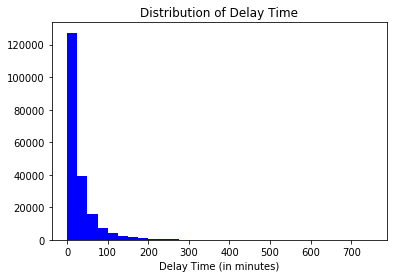

```python
# plot distribution of departure delay
binsize = 25
bins = np.arange(0, delayed_df['DepDelay'].max()+binsize, binsize)

plt.hist(data=delayed_df, x='DepDelay', bins = bins, color='blue');
plt.xlabel('Delay Time (in minutes)');
plt.title('Distribution of Delay Time');
```

```python
delayed_df.DepDelay.describe()
```

```
count    200802.000000
mean         28.770948
std          38.160447
min           1.000000
25%           6.000000
50%          15.000000
75%          35.000000
max         732.000000
Name: DepDelay, dtype: float64
```

This plot is a poor visualization of delay times. Let's look at this distribution using a log scale.

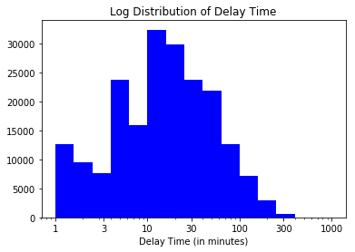

```python
log_binsize = 0.2
bins = 10 ** np.arange(0, np.log10(delayed_df['DepDelay'].max())+log_binsize, log_binsize)

plt.hist(data = delayed_df, x = 'DepDelay', bins = bins, color = 'blue');
plt.xscale('log');
plt.xticks([1e0, .333e1, 1e1, 3e1, 1e2, 3e2, 1e3], [1, 3, 10, 30, 100, 300, 1000])
plt.xlabel('Delay Time (in minutes)');
plt.title('Log Distribution of Delay Time');
```

Delay time has a long right-tailed distribution, with a lot of delayed flights on the low end and a few outliers at the high end.

When plotted as a log-scale, the delay time distribution looks roughly multi-modal, with one peak between 1-2, another peak from 4-6, and a final peak from 10-20.

I'm going to do a quick visual inspection at the departure delays above 300 minutes to see if any any of the outliers look to be due to miscoding.

```python
# querying DepDelay times > 300
delay_times = ['DepDelay', 'CarrierDelay', 'WeatherDelay', 'NASDelay', 'SecurityDelay', 'LateAircraftDelay']
delayed_df.query('DepDelay > 300')[delay_times]
```

|  | DepDelay | CarrierDelay | WeatherDelay | NASDelay | SecurityDelay | LateAircraftDelay |
| --- | --- | --- | --- | --- | --- | --- |
| 243 | 359.0 | 354.0 | 0.0 | 0.0 | 0.0 | 0.0 |
| 531 | 396.0 | 0.0 | 0.0 | 0.0 | 0.0 | 373.0 |
| 1106 | 354.0 | 28.0 | 0.0 | 5.0 | 0.0 | 326.0 |
| 1208 | 385.0 | 36.0 | 0.0 | 0.0 | 0.0 | 336.0 |
| 1353 | 381.0 | 0.0 | 381.0 | 14.0 | 0.0 | 0.0 |
| 1629 | 318.0 | 30.0 | 0.0 | 0.0 | 0.0 | 276.0 |
| 1683 | 405.0 | 28.0 | 0.0 | 0.0 | 0.0 | 369.0 |
| 1689 | 352.0 | 340.0 | 0.0 | 0.0 | 0.0 | 0.0 |
| 3028 | 526.0 | 509.0 | 0.0 | 0.0 | 0.0 | 0.0 |
| 3030 | 411.0 | 38.0 | 0.0 | 52.0 | 0.0 | 373.0 |
| 3779 | 349.0 | 0.0 | 0.0 | 407.0 | 0.0 | 0.0 |
| 4629 | 311.0 | 293.0 | 0.0 | 0.0 | 0.0 | 0.0 |
| 6280 | 335.0 | 0.0 | 0.0 | 346.0 | 0.0 | 0.0 |
| 6557 | 372.0 | 362.0 | 0.0 | 0.0 | 0.0 | 0.0 |
| 6915 | 326.0 | 110.0 | 0.0 | 0.0 | 0.0 | 195.0 |
| 7277 | 333.0 | 0.0 | 0.0 | 377.0 | 0.0 | 0.0 |
| 7570 | 303.0 | 16.0 | 0.0 | 18.0 | 0.0 | 287.0 |
| 7610 | 429.0 | 396.0 | 0.0 | 0.0 | 0.0 | 19.0 |
| 8122 | 358.0 | 0.0 | 0.0 | 0.0 | 0.0 | 358.0 |
| 8351 | 335.0 | 332.0 | 0.0 | 0.0 | 0.0 | 0.0 |
| 8527 | 496.0 | 496.0 | 0.0 | 16.0 | 0.0 | 0.0 |
| 9552 | 309.0 | 0.0 | 307.0 | 0.0 | 0.0 | 0.0 |
| 9632 | 640.0 | 15.0 | 0.0 | 4.0 | 0.0 | 625.0 |
| 9633 | 398.0 | 396.0 | 0.0 | 0.0 | 0.0 | 0.0 |
| 10440 | 332.0 | 0.0 | 0.0 | 354.0 | 0.0 | 0.0 |
| 10506 | 599.0 | 563.0 | 0.0 | 0.0 | 0.0 | 1.0 |
| 10655 | 365.0 | 339.0 | 0.0 | 0.0 | 0.0 | 0.0 |
| 10737 | 353.0 | 0.0 | 0.0 | 41.0 | 0.0 | 335.0 |
| 10793 | 395.0 | 395.0 | 0.0 | 4.0 | 0.0 | 0.0 |
| 10844 | 312.0 | 0.0 | 0.0 | 294.0 | 0.0 | 0.0 |
| ... | ... | ... | ... | ... | ... | ... |
| 146394 | 345.0 | 0.0 | 280.0 | 49.0 | 0.0 | 65.0 |
| 146402 | 378.0 | 0.0 | 0.0 | 0.0 | 0.0 | 365.0 |
| 146411 | 503.0 | 502.0 | 0.0 | 0.0 | 0.0 | 0.0 |
| 146414 | 343.0 | 0.0 | 343.0 | 55.0 | 0.0 | 0.0 |
| 146424 | 344.0 | 224.0 | 120.0 | 7.0 | 0.0 | 0.0 |
| 146430 | 403.0 | 0.0 | 0.0 | 401.0 | 0.0 | 0.0 |
| 146441 | 339.0 | 0.0 | 0.0 | 0.0 | 0.0 | 336.0 |
| 146733 | 483.0 | 461.0 | 0.0 | 0.0 | 0.0 | 0.0 |
| 146905 | 320.0 | 320.0 | 0.0 | 14.0 | 0.0 | 0.0 |
| 146962 | 374.0 | 62.0 | 0.0 | 0.0 | 0.0 | 311.0 |
| 147232 | 337.0 | 331.0 | 0.0 | 0.0 | 0.0 | 0.0 |
| 147243 | 316.0 | 311.0 | 0.0 | 0.0 | 0.0 | 0.0 |
| 173296 | 339.0 | 0.0 | 0.0 | 0.0 | 0.0 | 329.0 |
| 194692 | 324.0 | 0.0 | 321.0 | 0.0 | 0.0 | 0.0 |
| 195944 | 306.0 | 0.0 | 306.0 | 76.0 | 0.0 | 0.0 |
| 196280 | 301.0 | 0.0 | 0.0 | 307.0 | 0.0 | 0.0 |
| 196372 | 316.0 | 299.0 | 0.0 | 0.0 | 0.0 | 0.0 |
| 197238 | 304.0 | 304.0 | 0.0 | 15.0 | 0.0 | 0.0 |
| 197736 | 330.0 | 0.0 | 0.0 | 11.0 | 0.0 | 330.0 |
| 197878 | 310.0 | 0.0 | 0.0 | 297.0 | 0.0 | 0.0 |
| 197951 | 531.0 | 531.0 | 0.0 | 25.0 | 0.0 | 0.0 |
| 198080 | 415.0 | 413.0 | 0.0 | 0.0 | 0.0 | 0.0 |
| 198390 | 363.0 | 363.0 | 0.0 | 4.0 | 0.0 | 0.0 |
| 198800 | 326.0 | 0.0 | 326.0 | 1.0 | 0.0 | 0.0 |
| 199640 | 302.0 | 0.0 | 302.0 | 31.0 | 0.0 | 0.0 |
| 199933 | 348.0 | 0.0 | 348.0 | 3.0 | 0.0 | 0.0 |
| 199953 | 342.0 | 0.0 | 0.0 | 331.0 | 0.0 | 0.0 |
| 200346 | 442.0 | 426.0 | 0.0 | 0.0 | 0.0 | 0.0 |
| 200663 | 413.0 | 411.0 | 0.0 | 0.0 | 0.0 | 0.0 |
| 200784 | 326.0 | 0.0 | 321.0 | 0.0 | 0.0 | 0.0 |

250 rows × 6 columns

### What is the distribution of delay times for each delay type?

Let's look at the distribution of delay times for: CarrierDelay, WeatherDelay, NASDelay, SecurityDelay, LateAircraftDelay.

```python
# make histplot function
def nonzero_hist(df, col, x_label, bins):
    '''This function will plot a histogram for the non-zero entries in
    column of interest with a specified x_label, and specified number of bins.
    ---------------
    Parameters:
    df - the dataframe of interest
    col - the column of interest (PUT IN QUOTES)
    x_label - the string to use for the x-axis label (PUT IN QUOTES)
    bins = the number of bins to use'''

    #pull non-zero entries from column of interest
    data = df[df[col] != 0]
    #plot histogram of column of interest
    plt.hist(data = data, x = col, bins = bins, color = 'blue');
    plt.xlabel(x_label);
```

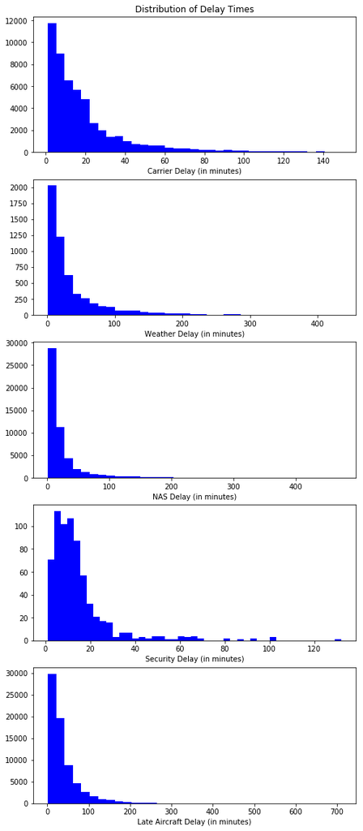

```python
# let's plot all five together to get an idea of each delay time variable's distribution.
fig = plt.figure(figsize = [8, 20])

fig.add_subplot(5, 1, 1)
plt.title('Distribution of Delay Times')
nonzero_hist(test, 'CarrierDelay', 'Carrier Delay (in minutes)', 35);

fig.add_subplot(5, 1, 2)
nonzero_hist(delayed_df, 'WeatherDelay', 'Weather Delay (in minutes)', 35);

fig.add_subplot(5, 1, 3)
nonzero_hist(delayed_df, 'NASDelay', 'NAS Delay (in minutes)', 35);

fig.add_subplot(5, 1, 4)
nonzero_hist(delayed_df, 'SecurityDelay', 'Security Delay (in minutes)', 45);

fig.add_subplot(5, 1, 5)
nonzero_hist(delayed_df, 'LateAircraftDelay', 'Late Aircraft Delay (in minutes)', 35);
```

All of the delay time variables are right-skewed with long tails suggesting strong outliers on the right. I will be looking at these outliers to see if they need to be filtered out of the data.

Overall it looks like it's not as common for delays to be long. Even at 100 minutes, there are relatively few in each delay type compared to the more frequent bins.

```python
#checking for outlier issues in CarrierDelay
delayed_df.query('CarrierDelay > 400')
```

|  | Year | Month | DayofMonth | DayOfWeek | DepTime | CRSDepTime | ArrTime | CRSArrTime | UniqueCarrier | FlightNum | ... | WeatherDelay | NASDelay | SecurityDelay | LateAircraftDelay | carrier | weather | nas | security | late | delay |
| --- | --- | --- | --- | --- | --- | --- | --- | --- | --- | --- | --- | --- | --- | --- | --- | --- | --- | --- | --- | --- | --- |
| 3028 | 2004 | 1 | 2 | 5.0 | 1926.0 | 1040.0 | 2329.0 | 1500.0 | UA | 690.0 | ... | 0.0 | 0.0 | 0.0 | 0.0 | c | None | None | None | None | c |
| 8527 | 2004 | 1 | 9 | 5.0 | 1521.0 | 705.0 | 2102.0 | 1230.0 | UA | 1184.0 | ... | 0.0 | 16.0 | 0.0 | 0.0 | c | None | n | None | None | c, n |
| 10506 | 2004 | 1 | 2 | 5.0 | 2309.0 | 1310.0 | 239.0 | 1715.0 | UA | 1448.0 | ... | 0.0 | 0.0 | 0.0 | 1.0 | c | None | None | None | l | c, l |
| 19566 | 2004 | 1 | 23 | 5.0 | 1914.0 | 955.0 | 2151.0 | 1234.0 | US | 490.0 | ... | 0.0 | 0.0 | 0.0 | 0.0 | c | None | None | None | None | c |
| 49878 | 2006 | 1 | 30 | 1.0 | 1948.0 | 800.0 | 2205.0 | 1021.0 | US | 788.0 | ... | 0.0 | 0.0 | 0.0 | 0.0 | c | None | None | None | None | c |
| 51569 | 2006 | 1 | 2 | 1.0 | 2332.0 | 1525.0 | 133.0 | 1735.0 | WN | 772.0 | ... | 0.0 | 0.0 | 0.0 | 25.0 | c | None | None | None | l | c, l |
| 78141 | 2005 | 1 | 3 | 1.0 | 1955.0 | 1107.0 | 133.0 | 1705.0 | UA | 646.0 | ... | 0.0 | 0.0 | 0.0 | 26.0 | c | None | None | None | l | c, l |
| 82714 | 2005 | 1 | 1 | 6.0 | 1838.0 | 830.0 | 2148.0 | 949.0 | UA | 1160.0 | ... | 0.0 | 111.0 | 0.0 | 0.0 | c | None | n | None | None | c, n |
| 84571 | 2005 | 1 | 1 | 6.0 | 1604.0 | 628.0 | 2116.0 | 1158.0 | UA | 1275.0 | ... | 0.0 | 0.0 | 0.0 | 0.0 | c | None | None | None | None | c |
| 94143 | 2005 | 1 | 22 | 6.0 | 1506.0 | 800.0 | 1656.0 | 915.0 | US | 451.0 | ... | 0.0 | 35.0 | 0.0 | 0.0 | c | None | n | None | None | c, n |
| 145140 | 2008 | 1 | 14 | 1.0 | 2346.0 | 1610.0 | 18.0 | 1707.0 | XE | 148.0 | ... | 0.0 | 0.0 | 0.0 | 0.0 | c | None | None | None | None | c |
| 145498 | 2008 | 1 | 16 | 3.0 | 1407.0 | 715.0 | 1736.0 | 1034.0 | XE | 400.0 | ... | 0.0 | 10.0 | 0.0 | 0.0 | c | None | n | None | None | c, n |
| 146411 | 2008 | 1 | 25 | 5.0 | 1608.0 | 745.0 | 1732.0 | 910.0 | XE | 7783.0 | ... | 0.0 | 0.0 | 0.0 | 0.0 | c | None | None | None | None | c |
| 146733 | 2008 | 1 | 2 | 3.0 | 1518.0 | 715.0 | 1630.0 | 849.0 | XE | 9.0 | ... | 0.0 | 0.0 | 0.0 | 0.0 | c | None | None | None | None | c |
| 197951 | 2007 | 1 | 8 | 1.0 | 2156.0 | 1305.0 | 1.0 | 1445.0 | XE | 2790.0 | ... | 0.0 | 25.0 | 0.0 | 0.0 | c | None | n | None | None | c, n |
| 198080 | 2007 | 1 | 28 | 7.0 | 1650.0 | 955.0 | 1834.0 | 1141.0 | XE | 2983.0 | ... | 0.0 | 0.0 | 0.0 | 0.0 | c | None | None | None | None | c |
| 200346 | 2007 | 1 | 15 | 1.0 | 2107.0 | 1345.0 | 2201.0 | 1455.0 | XE | 2860.0 | ... | 0.0 | 0.0 | 0.0 | 0.0 | c | None | None | None | None | c |
| 200663 | 2007 | 1 | 17 | 3.0 | 1553.0 | 900.0 | 2118.0 | 1427.0 | XE | 2608.0 | ... | 0.0 | 0.0 | 0.0 | 0.0 | c | None | None | None | None | c |

18 rows × 35 columns

```python
#checking for outlier issues in WeatherDelay
delayed_df.query('WeatherDelay > 300')
```

|  | Year | Month | DayofMonth | DayOfWeek | DepTime | CRSDepTime | ArrTime | CRSArrTime | UniqueCarrier | FlightNum | ... | WeatherDelay | NASDelay | SecurityDelay | LateAircraftDelay | carrier | weather | nas | security | late | delay |
| --- | --- | --- | --- | --- | --- | --- | --- | --- | --- | --- | --- | --- | --- | --- | --- | --- | --- | --- | --- | --- | --- |
| 1353 | 2004 | 1 | 25 | 7.0 | 1530.0 | 909.0 | 1705.0 | 1030.0 | UA | 555.0 | ... | 381.0 | 14.0 | 0.0 | 0.0 | None | w | n | None | None | w, n |
| 9552 | 2004 | 1 | 26 | 1.0 | 1834.0 | 1325.0 | 1947.0 | 1440.0 | UA | 1254.0 | ... | 307.0 | 0.0 | 0.0 | 0.0 | None | w | None | None | None | w |
| 31556 | 2004 | 1 | 4 | 7.0 | 1720.0 | 1110.0 | 2310.0 | 1640.0 | WN | 357.0 | ... | 350.0 | 20.0 | 0.0 | 20.0 | None | w | n | None | l | w, n, l |
| 33774 | 2004 | 1 | 14 | 3.0 | 1110.0 | 605.0 | 1211.0 | 705.0 | WN | 710.0 | ... | 305.0 | 1.0 | 0.0 | 0.0 | None | w | n | None | None | w, n |
| 35705 | 2004 | 1 | 4 | 7.0 | 2135.0 | 1420.0 | 25.0 | 1650.0 | WN | 327.0 | ... | 435.0 | 20.0 | 0.0 | 0.0 | None | w | n | None | None | w, n |
| 49625 | 2006 | 1 | 30 | 1.0 | 1336.0 | 725.0 | 1514.0 | 856.0 | US | 125.0 | ... | 371.0 | 7.0 | 0.0 | 0.0 | None | w | n | None | None | w, n |
| 79897 | 2005 | 1 | 21 | 5.0 | 300.0 | 2055.0 | 657.0 | 2343.0 | UA | 766.0 | ... | 309.0 | 69.0 | 0.0 | 56.0 | None | w | n | None | l | w, n, l |
| 122155 | 2005 | 1 | 13 | 4.0 | 2125.0 | 1550.0 | 40.0 | 1905.0 | WN | 717.0 | ... | 335.0 | 0.0 | 0.0 | 0.0 | None | w | None | None | None | w |
| 146089 | 2008 | 1 | 4 | 5.0 | 1501.0 | 815.0 | 1701.0 | 933.0 | XE | 7754.0 | ... | 406.0 | 42.0 | 0.0 | 0.0 | None | w | n | None | None | w, n |
| 146414 | 2008 | 1 | 4 | 5.0 | 2338.0 | 1755.0 | 201.0 | 1923.0 | XE | 7784.0 | ... | 343.0 | 55.0 | 0.0 | 0.0 | None | w | n | None | None | w, n |
| 194692 | 2007 | 1 | 16 | 2.0 | 1104.0 | 540.0 | 1154.0 | 633.0 | XE | 2339.0 | ... | 321.0 | 0.0 | 0.0 | 0.0 | None | w | None | None | None | w |
| 195944 | 2007 | 1 | 16 | 2.0 | 211.0 | 2105.0 | 459.0 | 2237.0 | XE | 2280.0 | ... | 306.0 | 76.0 | 0.0 | 0.0 | None | w | n | None | None | w, n |
| 198800 | 2007 | 1 | 16 | 2.0 | 1101.0 | 535.0 | 1209.0 | 642.0 | XE | 3112.0 | ... | 326.0 | 1.0 | 0.0 | 0.0 | None | w | n | None | None | w, n |
| 199640 | 2007 | 1 | 16 | 2.0 | 2341.0 | 1839.0 | 331.0 | 2158.0 | XE | 2375.0 | ... | 302.0 | 31.0 | 0.0 | 0.0 | None | w | n | None | None | w, n |
| 199933 | 2007 | 1 | 16 | 2.0 | 1153.0 | 605.0 | 1343.0 | 752.0 | XE | 3013.0 | ... | 348.0 | 3.0 | 0.0 | 0.0 | None | w | n | None | None | w, n |
| 200784 | 2007 | 1 | 16 | 2.0 | 1051.0 | 525.0 | 1158.0 | 637.0 | XE | 2004.0 | ... | 321.0 | 0.0 | 0.0 | 0.0 | None | w | None | None | None | w |

16 rows × 35 columns

```python
#checking for outlier issues in NASDelay
delayed_df.query('NASDelay > 300')
```

|  | Year | Month | DayofMonth | DayOfWeek | DepTime | CRSDepTime | ArrTime | CRSArrTime | UniqueCarrier | FlightNum | ... | WeatherDelay | NASDelay | SecurityDelay | LateAircraftDelay | carrier | weather | nas | security | late | delay |
| --- | --- | --- | --- | --- | --- | --- | --- | --- | --- | --- | --- | --- | --- | --- | --- | --- | --- | --- | --- | --- | --- |
| 425 | 2004 | 1 | 2 | 5.0 | 1930.0 | 1455.0 | 2118.0 | 1555.0 | UA | 489.0 | ... | 0.0 | 323.0 | 0.0 | 0.0 | None | None | n | None | None | n |
| 606 | 2004 | 1 | 4 | 7.0 | 1934.0 | 1456.0 | 2120.0 | 1604.0 | UA | 501.0 | ... | 0.0 | 307.0 | 0.0 | 9.0 | None | None | n | None | l | n, l |
| 1037 | 2004 | 1 | 4 | 7.0 | 1715.0 | 1215.0 | 1940.0 | 1356.0 | UA | 535.0 | ... | 0.0 | 344.0 | 0.0 | 0.0 | None | None | n | None | None | n |
| 1561 | 2004 | 1 | 4 | 7.0 | 1604.0 | 1104.0 | 2249.0 | 1713.0 | UA | 568.0 | ... | 0.0 | 315.0 | 0.0 | 21.0 | None | None | n | None | l | n, l |
| 3779 | 2004 | 1 | 4 | 7.0 | 1819.0 | 1230.0 | 2036.0 | 1349.0 | UA | 741.0 | ... | 0.0 | 407.0 | 0.0 | 0.0 | None | None | n | None | None | n |
| 6278 | 2004 | 1 | 2 | 5.0 | 1640.0 | 1230.0 | 1951.0 | 1450.0 | UA | 1016.0 | ... | 0.0 | 301.0 | 0.0 | 0.0 | None | None | n | None | None | n |
| 6280 | 2004 | 1 | 4 | 7.0 | 1805.0 | 1230.0 | 2036.0 | 1450.0 | UA | 1016.0 | ... | 0.0 | 346.0 | 0.0 | 0.0 | None | None | n | None | None | n |
| 7277 | 2004 | 1 | 4 | 7.0 | 1833.0 | 1300.0 | 2014.0 | 1357.0 | UA | 1097.0 | ... | 0.0 | 377.0 | 0.0 | 0.0 | None | None | n | None | None | n |
| 7441 | 2004 | 1 | 4 | 7.0 | 1733.0 | 1241.0 | 2027.0 | 1510.0 | UA | 1110.0 | ... | 0.0 | 305.0 | 0.0 | 12.0 | None | None | n | None | l | n, l |
| 7527 | 2004 | 1 | 4 | 7.0 | 2030.0 | 1535.0 | 2125.0 | 1557.0 | UA | 1115.0 | ... | 0.0 | 328.0 | 0.0 | 0.0 | None | None | n | None | None | n |
| 7566 | 2004 | 1 | 4 | 7.0 | 1238.0 | 842.0 | 1507.0 | 1005.0 | UA | 1116.0 | ... | 0.0 | 302.0 | 0.0 | 0.0 | None | None | n | None | None | n |
| 7654 | 2004 | 1 | 4 | 7.0 | 1449.0 | 1030.0 | 1954.0 | 1448.0 | UA | 1122.0 | ... | 0.0 | 306.0 | 0.0 | 0.0 | None | None | n | None | None | n |
| 9658 | 2004 | 1 | 26 | 1.0 | 1732.0 | 1245.0 | 1935.0 | 1352.0 | UA | 1263.0 | ... | 0.0 | 343.0 | 0.0 | 0.0 | None | None | n | None | None | n |
| 10440 | 2004 | 1 | 4 | 7.0 | 1827.0 | 1255.0 | 1935.0 | 1341.0 | UA | 1435.0 | ... | 0.0 | 354.0 | 0.0 | 0.0 | None | None | n | None | None | n |
| 10750 | 2004 | 1 | 2 | 5.0 | 1349.0 | 1249.0 | 1902.0 | 1400.0 | UA | 1503.0 | ... | 0.0 | 302.0 | 0.0 | 0.0 | None | None | n | None | None | n |
| 10900 | 2004 | 1 | 4 | 7.0 | 1259.0 | 1100.0 | 1622.0 | 1109.0 | UA | 1540.0 | ... | 0.0 | 313.0 | 0.0 | 0.0 | None | None | n | None | None | n |
| 10932 | 2004 | 1 | 4 | 7.0 | 1629.0 | 1119.0 | 1742.0 | 1230.0 | UA | 1547.0 | ... | 0.0 | 312.0 | 0.0 | 0.0 | None | None | n | None | None | n |
| 11033 | 2004 | 1 | 4 | 7.0 | 1759.0 | 1245.0 | 1953.0 | 1351.0 | UA | 1565.0 | ... | 0.0 | 362.0 | 0.0 | 0.0 | None | None | n | None | None | n |
| 11083 | 2004 | 1 | 2 | 5.0 | 1440.0 | 845.0 | 2007.0 | 1454.0 | UA | 1574.0 | ... | 0.0 | 313.0 | 0.0 | 0.0 | None | None | n | None | None | n |
| 11085 | 2004 | 1 | 4 | 7.0 | 1505.0 | 845.0 | 2053.0 | 1454.0 | UA | 1574.0 | ... | 0.0 | 359.0 | 0.0 | 0.0 | None | None | n | None | None | n |
| 78219 | 2005 | 1 | 22 | 6.0 | 1633.0 | 1106.0 | 2243.0 | 1659.0 | UA | 650.0 | ... | 0.0 | 344.0 | 0.0 | 0.0 | None | None | n | None | None | n |
| 78228 | 2005 | 1 | 5 | 3.0 | 2100.0 | 1645.0 | 2400.0 | 1822.0 | UA | 651.0 | ... | 0.0 | 318.0 | 0.0 | 20.0 | None | None | n | None | l | n, l |
| 78422 | 2005 | 1 | 5 | 3.0 | 1907.0 | 1346.0 | 1931.0 | 1415.0 | UA | 665.0 | ... | 0.0 | 314.0 | 0.0 | 2.0 | None | None | n | None | l | n, l |
| 78626 | 2005 | 1 | 5 | 3.0 | 2021.0 | 1500.0 | 2211.0 | 1635.0 | UA | 685.0 | ... | 0.0 | 336.0 | 0.0 | 0.0 | None | None | n | None | None | n |
| 78671 | 2005 | 1 | 5 | 3.0 | 2123.0 | 1700.0 | 30.0 | 1839.0 | UA | 689.0 | ... | 0.0 | 351.0 | 0.0 | 0.0 | None | None | n | None | None | n |
| 78697 | 2005 | 1 | 22 | 6.0 | 1810.0 | 1230.0 | 2022.0 | 1452.0 | UA | 690.0 | ... | 0.0 | 330.0 | 0.0 | 0.0 | None | None | n | None | None | n |
| 78734 | 2005 | 1 | 5 | 3.0 | 1601.0 | 952.0 | 2211.0 | 1559.0 | UA | 694.0 | ... | 0.0 | 372.0 | 0.0 | 0.0 | None | None | n | None | None | n |
| 79590 | 2005 | 1 | 5 | 3.0 | 1930.0 | 1402.0 | 2157.0 | 1609.0 | UA | 749.0 | ... | 0.0 | 314.0 | 0.0 | 34.0 | None | None | n | None | l | n, l |
| 79982 | 2005 | 1 | 5 | 3.0 | 1547.0 | 800.0 | 2019.0 | 1226.0 | UA | 772.0 | ... | 0.0 | 473.0 | 0.0 | 0.0 | None | None | n | None | None | n |
| 80875 | 2005 | 1 | 22 | 6.0 | 1638.0 | 1150.0 | 2306.0 | 1758.0 | UA | 870.0 | ... | 0.0 | 308.0 | 0.0 | 0.0 | None | None | n | None | None | n |
| 81621 | 2005 | 1 | 5 | 3.0 | 1315.0 | 1055.0 | 2243.0 | 1700.0 | UA | 940.0 | ... | 0.0 | 343.0 | 0.0 | 0.0 | None | None | n | None | None | n |
| 81628 | 2005 | 1 | 22 | 6.0 | 1626.0 | 1106.0 | 2238.0 | 1705.0 | UA | 940.0 | ... | 0.0 | 333.0 | 0.0 | 0.0 | None | None | n | None | None | n |
| 82562 | 2005 | 1 | 5 | 3.0 | 1557.0 | 1148.0 | 2024.0 | 1329.0 | UA | 1149.0 | ... | 0.0 | 415.0 | 0.0 | 0.0 | None | None | n | None | None | n |
| 83156 | 2005 | 1 | 5 | 3.0 | 1919.0 | 1530.0 | 2242.0 | 1700.0 | UA | 1190.0 | ... | 0.0 | 321.0 | 0.0 | 21.0 | None | None | n | None | l | n, l |
| 83220 | 2005 | 1 | 5 | 3.0 | 1812.0 | 1215.0 | 1957.0 | 1357.0 | UA | 1195.0 | ... | 0.0 | 360.0 | 0.0 | 0.0 | None | None | n | None | None | n |
| 83373 | 2005 | 1 | 22 | 6.0 | 1639.0 | 1105.0 | 2249.0 | 1659.0 | UA | 1204.0 | ... | 0.0 | 350.0 | 0.0 | 0.0 | None | None | n | None | None | n |
| 83480 | 2005 | 1 | 5 | 3.0 | 1452.0 | 845.0 | 2104.0 | 1450.0 | UA | 1214.0 | ... | 0.0 | 374.0 | 0.0 | 0.0 | None | None | n | None | None | n |
| 84231 | 2005 | 1 | 5 | 3.0 | 2119.0 | 1655.0 | 2341.0 | 1819.0 | UA | 1253.0 | ... | 0.0 | 322.0 | 0.0 | 0.0 | None | None | n | None | None | n |
| 84410 | 2005 | 1 | 22 | 6.0 | 1941.0 | 1402.0 | 2150.0 | 1605.0 | UA | 1263.0 | ... | 0.0 | 345.0 | 0.0 | 0.0 | None | None | n | None | None | n |
| 84736 | 2005 | 1 | 5 | 3.0 | 2022.0 | 1500.0 | 2140.0 | 1615.0 | UA | 1287.0 | ... | 0.0 | 325.0 | 0.0 | 0.0 | None | None | n | None | None | n |
| 86227 | 2005 | 1 | 22 | 6.0 | 1731.0 | 1209.0 | 2200.0 | 1629.0 | UA | 1486.0 | ... | 0.0 | 331.0 | 0.0 | 0.0 | None | None | n | None | None | n |
| 87091 | 2005 | 1 | 22 | 6.0 | 1837.0 | 1330.0 | 2136.0 | 1528.0 | UA | 1535.0 | ... | 0.0 | 368.0 | 0.0 | 0.0 | None | None | n | None | None | n |
| 87935 | 2005 | 1 | 22 | 6.0 | 1545.0 | 1038.0 | 2214.0 | 1615.0 | UA | 1594.0 | ... | 0.0 | 359.0 | 0.0 | 0.0 | None | None | n | None | None | n |
| 93603 | 2005 | 1 | 19 | 3.0 | 1755.0 | 1320.0 | 2013.0 | 1435.0 | US | 385.0 | ... | 0.0 | 331.0 | 0.0 | 7.0 | None | None | n | None | l | n, l |
| 93641 | 2005 | 1 | 19 | 3.0 | 1814.0 | 1330.0 | 1959.0 | 1438.0 | US | 390.0 | ... | 0.0 | 315.0 | 0.0 | 6.0 | None | None | n | None | l | n, l |
| 95740 | 2005 | 1 | 29 | 6.0 | 100.0 | 1955.0 | 317.0 | 2133.0 | US | 628.0 | ... | 0.0 | 344.0 | 0.0 | 0.0 | None | None | n | None | None | n |
| 99224 | 2005 | 1 | 19 | 3.0 | 1645.0 | 1145.0 | 1806.0 | 1256.0 | US | 1045.0 | ... | 0.0 | 310.0 | 0.0 | 0.0 | None | None | n | None | None | n |
| 132056 | 2008 | 1 | 7 | 1.0 | 2143.0 | 1720.0 | 26.0 | 1820.0 | WN | 1430.0 | ... | 0.0 | 366.0 | 0.0 | 0.0 | None | None | n | None | None | n |
| 143077 | 2008 | 1 | 29 | 2.0 | 2310.0 | 1810.0 | 41.0 | 1930.0 | WN | 36.0 | ... | 0.0 | 305.0 | 0.0 | 6.0 | None | None | n | None | l | n, l |
| 144233 | 2008 | 1 | 31 | 4.0 | 2244.0 | 1810.0 | 127.0 | 1930.0 | WN | 36.0 | ... | 0.0 | 320.0 | 0.0 | 37.0 | None | None | n | None | l | n, l |
| 145463 | 2008 | 1 | 27 | 7.0 | 1750.0 | 1330.0 | 2247.0 | 1720.0 | XE | 319.0 | ... | 0.0 | 302.0 | 0.0 | 25.0 | None | None | n | None | l | n, l |
| 146430 | 2008 | 1 | 4 | 5.0 | 233.0 | 1950.0 | 349.0 | 2108.0 | XE | 7784.0 | ... | 0.0 | 401.0 | 0.0 | 0.0 | None | None | n | None | None | n |
| 196280 | 2007 | 1 | 16 | 2.0 | 1046.0 | 545.0 | 1136.0 | 629.0 | XE | 3059.0 | ... | 0.0 | 307.0 | 0.0 | 0.0 | None | None | n | None | None | n |
| 199953 | 2007 | 1 | 16 | 2.0 | 1054.0 | 512.0 | 1210.0 | 639.0 | XE | 3014.0 | ... | 0.0 | 331.0 | 0.0 | 0.0 | None | None | n | None | None | n |

54 rows × 35 columns

```python
#checking for outlier issues in SecuirtyDelay
delayed_df.query('SecurityDelay > 80')
```

|  | Year | Month | DayofMonth | DayOfWeek | DepTime | CRSDepTime | ArrTime | CRSArrTime | UniqueCarrier | FlightNum | ... | WeatherDelay | NASDelay | SecurityDelay | LateAircraftDelay | carrier | weather | nas | security | late | delay |
| --- | --- | --- | --- | --- | --- | --- | --- | --- | --- | --- | --- | --- | --- | --- | --- | --- | --- | --- | --- | --- | --- |
| 29049 | 2004 | 1 | 12 | 1.0 | 745.0 | 605.0 | 950.0 | 805.0 | WN | 1130.0 | ... | 0.0 | 5.0 | 100.0 | 0.0 | None | None | n | s | None | n, s |
| 36049 | 2004 | 1 | 9 | 5.0 | 1740.0 | 1505.0 | 2007.0 | 1755.0 | WN | 1003.0 | ... | 0.0 | 0.0 | 132.0 | 0.0 | None | None | None | s | None | s |
| 109883 | 2005 | 1 | 3 | 1.0 | 1755.0 | 1445.0 | 1915.0 | 1610.0 | WN | 248.0 | ... | 0.0 | 0.0 | 93.0 | 92.0 | None | None | None | s | l | s, l |
| 139746 | 2008 | 1 | 25 | 5.0 | 1409.0 | 1240.0 | 1413.0 | 1245.0 | WN | 459.0 | ... | 0.0 | 0.0 | 88.0 | 0.0 | None | None | None | s | None | s |
| 155740 | 2007 | 1 | 5 | 5.0 | 1343.0 | 1200.0 | 1456.0 | 1315.0 | WN | 1864.0 | ... | 0.0 | 0.0 | 101.0 | 0.0 | None | None | None | s | None | s |
| 155747 | 2007 | 1 | 5 | 5.0 | 1405.0 | 1225.0 | 1656.0 | 1515.0 | WN | 149.0 | ... | 0.0 | 1.0 | 100.0 | 0.0 | None | None | n | s | None | n, s |
| 155765 | 2007 | 1 | 5 | 5.0 | 1407.0 | 1225.0 | 1520.0 | 1345.0 | WN | 2044.0 | ... | 0.0 | 0.0 | 93.0 | 2.0 | None | None | None | s | l | s, l |

7 rows × 35 columns

```python
#checking for outlier issues in LateAircraftDelay
delayed_df.query('LateAircraftDelay > 400')
```

|  | Year | Month | DayofMonth | DayOfWeek | DepTime | CRSDepTime | ArrTime | CRSArrTime | UniqueCarrier | FlightNum | ... | WeatherDelay | NASDelay | SecurityDelay | LateAircraftDelay | carrier | weather | nas | security | late | delay |
| --- | --- | --- | --- | --- | --- | --- | --- | --- | --- | --- | --- | --- | --- | --- | --- | --- | --- | --- | --- | --- | --- |
| 9632 | 2004 | 1 | 3 | 6.0 | 2036.0 | 956.0 | 2224.0 | 1140.0 | UA | 1262.0 | ... | 0.0 | 4.0 | 0.0 | 625.0 | c | None | n | None | l | c, n, l |
| 19326 | 2004 | 1 | 3 | 6.0 | 202.0 | 1350.0 | 447.0 | 1656.0 | US | 283.0 | ... | 0.0 | 0.0 | 0.0 | 710.0 | c | None | None | None | l | c, l |
| 19645 | 2004 | 1 | 9 | 5.0 | 2142.0 | 1155.0 | 2357.0 | 1434.0 | US | 530.0 | ... | 0.0 | 0.0 | 0.0 | 563.0 | None | None | None | None | l | l |
| 19820 | 2004 | 1 | 5 | 1.0 | 2058.0 | 900.0 | 354.0 | 1629.0 | US | 668.0 | ... | 0.0 | 0.0 | 0.0 | 685.0 | None | None | None | None | l | l |
| 36147 | 2004 | 1 | 4 | 7.0 | 2240.0 | 1525.0 | 120.0 | 1745.0 | WN | 480.0 | ... | 33.0 | 20.0 | 0.0 | 402.0 | None | w | n | None | l | w, n, l |
| 36192 | 2004 | 1 | 4 | 7.0 | 2105.0 | 1340.0 | 2347.0 | 1600.0 | WN | 2899.0 | ... | 15.0 | 22.0 | 0.0 | 430.0 | None | w | n | None | l | w, n, l |
| 78125 | 2005 | 1 | 20 | 4.0 | 1615.0 | 756.0 | 2010.0 | 1215.0 | UA | 646.0 | ... | 28.0 | 0.0 | 0.0 | 447.0 | None | w | None | None | l | w, l |
| 80063 | 2005 | 1 | 4 | 2.0 | 2251.0 | 1501.0 | 2355.0 | 1613.0 | UA | 779.0 | ... | 0.0 | 0.0 | 0.0 | 462.0 | None | None | None | None | l | l |
| 83191 | 2005 | 1 | 23 | 7.0 | 1321.0 | 600.0 | 1505.0 | 723.0 | UA | 1192.0 | ... | 0.0 | 21.0 | 0.0 | 423.0 | c | None | n | None | l | c, n, l |
| 84548 | 2005 | 1 | 5 | 3.0 | 200.0 | 1847.0 | 220.0 | 1908.0 | UA | 1273.0 | ... | 19.0 | 0.0 | 0.0 | 413.0 | None | w | None | None | l | w, l |
| 85789 | 2005 | 1 | 9 | 7.0 | 1516.0 | 755.0 | 1819.0 | 1101.0 | UA | 1462.0 | ... | 0.0 | 0.0 | 0.0 | 438.0 | None | None | None | None | l | l |
| 130184 | 2008 | 1 | 5 | 6.0 | 2243.0 | 1415.0 | 45.0 | 1625.0 | WN | 1684.0 | ... | 0.0 | 0.0 | 0.0 | 434.0 | c | None | None | None | l | c, l |
| 144381 | 2008 | 1 | 31 | 4.0 | 111.0 | 1635.0 | 351.0 | 1945.0 | WN | 440.0 | ... | 52.0 | 0.0 | 0.0 | 434.0 | None | w | None | None | l | w, l |
| 145505 | 2008 | 1 | 16 | 3.0 | 1801.0 | 1105.0 | 1912.0 | 1216.0 | XE | 401.0 | ... | 0.0 | 0.0 | 0.0 | 416.0 | None | None | None | None | l | l |

14 rows × 35 columns

It doesn't look like any of the outliers have any data issues. All the long delay type times were paired with an equally as large general delay time.

Since this didn't indicate any issues, I want to look at the delay type times under a log transformation.

```python
# create function for plotting each delay type with a log transformation
def log_delaytype(df, col, log_bins, title):
    '''This function will plot a histogram for the non-zero entries in a
    specific delay type column using a log scale.
    ---------------
    Parameters:
    df - the dataframe of interest
    col - the column of interest (PUT IN QUOTES)
    log_bins - the size of the log bins to use (best to keep between 0.05 & 0.2)
    title - the string to use for the historgram title (PUT IN QUOTES)'''

    #setting up bins
    log_binsize = log_bins
    bins = 10 ** np.arange(0, np.log10(df[col].max())+log_binsize, log_binsize)

    #pull non-zero entries from column of interest
    data = df[df[col] != 0]

    #plotting histogram
    plt.hist(data = df, x = col, bins = bins, color = 'blue');
    plt.xscale('log');
    plt.xticks([1e0, .333e1, 1e1, 3e1, 1e2, 3e2, 1e3], [1, 3, 10, 30, 100, 300, 1000])
    plt.xlabel('Delay Time (in minutes)');
    plt.title(title);
```

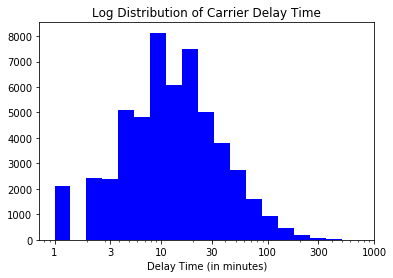

```python
log_delaytype(delayed_df, "CarrierDelay", .15, "Log Distribution of Carrier Delay Time")
```

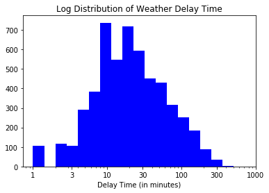

```python
log_delaytype(delayed_df, "WeatherDelay", .15, "Log Distribution of Weather Delay Time")
```

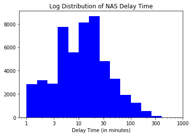

```python
log_delaytype(delayed_df, "NASDelay", .2, "Log Distribution of NAS Delay Time")
```

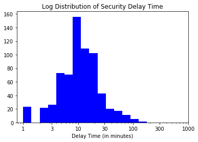

```python
log_delaytype(delayed_df, "SecurityDelay", .15, "Log Distribution of Security Delay Time")
```

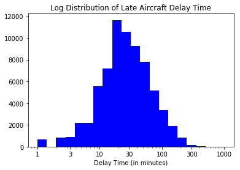

```python
log_delaytype(delayed_df, "LateAircraftDelay", .15, "Log Distribution of Late Aircraft Delay Time")
```

Interestingly enough, after applying a log transformation to each delay type, they all appear uni-modal with the following peaks:

- Carrier Delay: 3-40 minutes
- Weather Delay: 10-50 minutes
- NAS Delay: 3-40 minutes
- Secuity Delay: 5-25 minutes
- Late Aircraft Delay: 9-80 minutes

I also think it's interesting that all the delay type peaks start at around similar times at or below 10 minutes. I also find it interesting that none of the upper bounds go above 100 minutes.

### What are the most frequent reasons for departure delays?

```python
#getting non-zero & non-null delay counts for each delay type
c = delayed_df.query('carrier!="None"').shape[0]
w = delayed_df.query('weather!="None"').shape[0]
n = delayed_df.query('nas!="None"').shape[0]
s = delayed_df.query('security!="None"').shape[0]
l = delayed_df.query('late!="None"').shape[0]

#creating dictionary with delay types & counts
delay_types = {'Carrier': c, 'Weather': w, 'NAS': n, 'Security': s, 'Late Aircraft':l}

#sorting each item pair by the key values & converting back to dict
delay_types = dict(sorted(delay_types.items(), key=lambda x:x[1]))
```

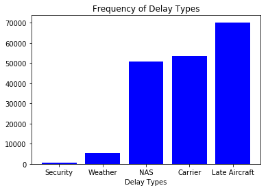

```python
#plot bar chart with counts of each delay type
plt.bar(x = range(len(delay_types.keys())), height = list(delay_types.values()),
        tick_label = list(delay_types.keys()), color = 'blue');
plt.xlabel('Delay Types');
plt.title('Frequency of Delay Types');
```

The majority of the aircraft delays are due to the NAS (National Aviation System), carriers or late aircrafts. It looks like it is relatively rare for a security delay to occur.

### What airline carriers are departing late more often than others?

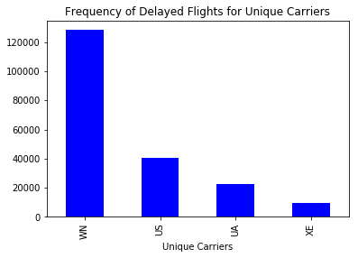

```python
#plot barchart for distribution of delayed flights by unique carriers
ind = delayed_df['UniqueCarrier'].value_counts().index;
delayed_df['UniqueCarrier'].value_counts()[ind].plot(kind = "bar", color='blue');
plt.xlabel('Unique Carriers');
plt.title('Frequency of Delayed Flights for Unique Carriers');
```

The carrier with the highest frequency of delayed flights is WN.

### What airports are most often departing late?

Let's look at the frequency at which each airport (as an origin & destination) has departure delays.

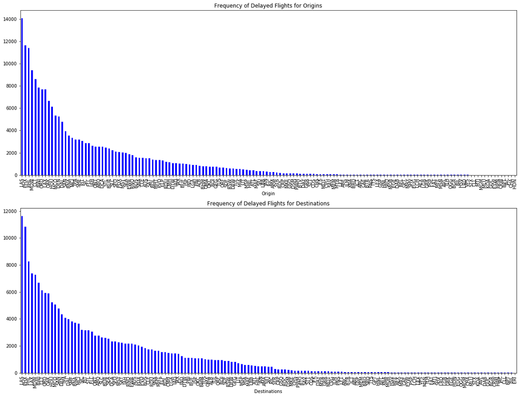

```python
plt.figure(figsize=[20, 15])

plt.subplot(2, 1, 1)
delayed_df.Origin.value_counts().plot(kind = "bar", color='blue');
plt.xlabel('Origin');
plt.title('Frequency of Delayed Flights for Origins');

plt.subplot(2, 1, 2)
delayed_df.Dest.value_counts().plot(kind = "bar", color='blue');
plt.xlabel('Destinations');
plt.title('Frequency of Delayed Flights for Destinations');
```

```python
print(len(delayed_df.Origin.unique()))
print(len(delayed_df.Dest.unique()))
```

```
148
149
```

There are quite a few Origins and Destinations. I want to focus on the top 10 origins and destinations with delayed flights. This seems to be a natural divide in frequency of delayed flights.

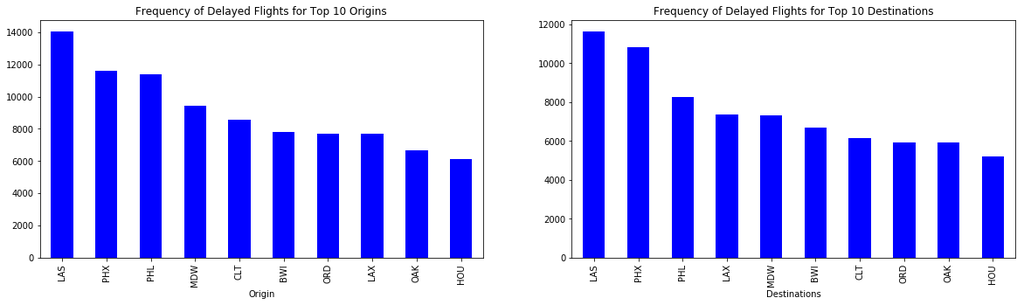

```python
plt.figure(figsize=[20, 5])

plt.subplot(1, 2, 1)
ind = delayed_df.Origin.value_counts().head(10).index;
delayed_df.Origin.value_counts()[ind].plot(kind = "bar", color='blue');
plt.xlabel('Origin');
plt.title('Frequency of Delayed Flights for Top 10 Origins');

plt.subplot(1, 2, 2)
ind = delayed_df.Dest.value_counts().head(10).index;
delayed_df.Dest.value_counts()[ind].plot(kind = "bar", color='blue');
plt.xlabel('Destinations');
plt.title('Frequency of Delayed Flights for Top 10 Destinations');
```

Although in different orders, the top 10 origins and destinations for delayed flights are all the same:

- LAS, PHX, PHL, MDW, CLT, BWI, ORD, LAX, OAK, & HOU

Interestingly: LAS, PHS, and PHL (in this order) are the top 3 locations for delayed flights for both origins and destinations.

### How does the frequency of delayed flights vary day by day?

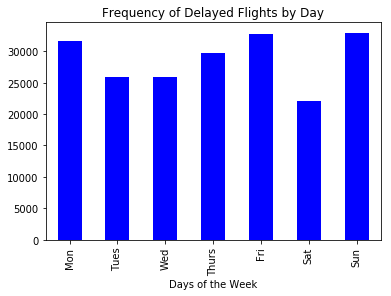

```python
#plot distribution of delayed flights by day of the week
ind = delayed_df['DayOfWeek'].value_counts().index;
delayed_df['DayOfWeek'].value_counts()[ind].sort_index().plot(kind = "bar", color='blue');

plt.xticks([0, 1, 2, 3, 4, 5, 6], ['Mon', 'Tues', 'Wed', 'Thurs', 'Fri', 'Sat', 'Sun']);
plt.xlabel('Days of the Week');
plt.title('Frequency of Delayed Flights by Day');
```

Saturday looks to have the lowest frequeny of delayed flights (about 1/3 less than the highest days). Monday, Fri & Sunday look to have the highest frequency of delayed flights, but not by any significant amount.

### Discuss the distribution(s) of your variable(s) of interest. Were there any unusual points? Did you need to perform any transformations?

> The delay times took on a long-tail right skew, so I performed a log transform. Under the distribution the data looks roughly multi-modal with one peak between 1-2, another peak from 4-6, and a final peak from 10-20.

### Of the features you investigated, were there any unusual distributions? Did you perform any operations on the data to tidy, adjust, or change the form of the data? If so, why did you do this?

> I needed to perform a log transform on the times for each delay type (as I did with the general delay time). I found it interesting that they were all roughly uni-modal and had peaks with similar lower bounds (all at or below 10). I also found it interesting that none of the peaks had upper bounds greater than 100.

> As far as adjusting the data, I did consider cutting out outlier delay time data. I ultimately decided not to because the outliers weren't due to miscoding & the large delay times could have useful information.

## Bivariate Exploration

### What is the correlation between departure delay time & each individual delay type length?

Keep in mind that there are multiple delays that can go into the overall departure delay.

```python
quant_vars = ['DepDelay', 'CarrierDelay', 'WeatherDelay', 'NASDelay', 'SecurityDelay', 'LateAircraftDelay']
```

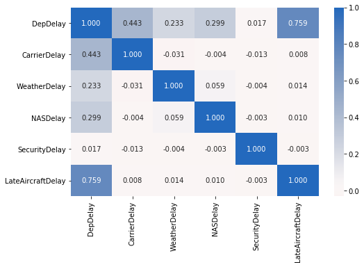

```python
# correlation plot for all delay times
plt.figure(figsize = [8, 5])
sb.heatmap(delayed_df[quant_vars].corr(), annot = True, fmt = '.3f',
           cmap = 'vlag_r', center = 0);
```

It looks like if a flight is delayed, there is a 75% correlation between the departure delay time and late aircraft delay. Then there is a 44% correlation between departure delay time and carrier delay.

This is interesting because when I looked at the frequency counts of delay types late aircrafts, carriers, and NAS all had high frequencies. However, late aircraft delays did seem to have a higher time peak in its distribution.

I want to look further at the relationship between departure delay time and late delays, carrier delays, and NAS delays.

### How does departure delay time vary as late aircraft/carrier/nas delay times increase?

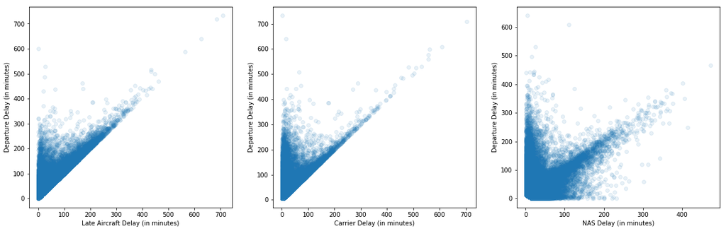

```python
# plotting scatter plot of positive late aircraft delay times against departure delay times
plt.figure(figsize = [20, 6])

plt.subplot(1, 3, 1)
plt.scatter(data = delayed_df.query('LateAircraftDelay > 0'), x = 'LateAircraftDelay', y = 'DepDelay', alpha = 0.1);
plt.xlabel('Late Aircraft Delay (in minutes)');
plt.ylabel('Departure Delay (in minutes)');

plt.subplot(1, 3, 2)
plt.scatter(data = delayed_df.query('CarrierDelay > 0'), x = 'CarrierDelay', y = 'DepDelay', alpha = 0.1);
plt.xlabel('Carrier Delay (in minutes)');
plt.ylabel('Departure Delay (in minutes)');

plt.subplot(1, 3, 3)
plt.scatter(data = delayed_df.query('NASDelay > 0'), x = 'NASDelay', y = 'DepDelay', alpha = 0.1);
plt.xlabel('NAS Delay (in minutes)');
plt.ylabel('Departure Delay (in minutes)');
```

As the heatmap indicated, the relationship between departure delay time and NAS delay time is very weak. As for Late Aircraft delay times and Carrier Delay times, the relationship appears to be weak for times under 80 minutes. I want to look at these scatterplots again but for with a log transform on departure delay time.

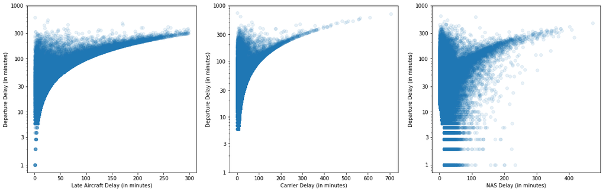

```python
# plotting scatter plot of positive late aircraft delay times against departure delay times
plt.figure(figsize = [20, 6])

plt.subplot(1, 3, 1)
plt.scatter(data = delayed_df.query('LateAircraftDelay > 0').query('LateAircraftDelay < 300'), x = 'LateAircraftDelay', y = 'DepDelay', alpha = 0.1);
plt.yscale('log');
plt.yticks([1e0, .333e1, 1e1, 3e1, 1e2, 3e2, 1e3], [1, 3, 10, 30, 100, 300, 1000]);
plt.xlabel('Late Aircraft Delay (in minutes)');
plt.ylabel('Departure Delay (in minutes)');

plt.subplot(1, 3, 2)
plt.scatter(data = delayed_df.query('CarrierDelay > 0'), x = 'CarrierDelay', y = 'DepDelay', alpha = 0.1);
plt.yscale('log');
plt.yticks([1e0, .333e1, 1e1, 3e1, 1e2, 3e2, 1e3], [1, 3, 10, 30, 100, 300, 1000]);
plt.xlabel('Carrier Delay (in minutes)');
plt.ylabel('Departure Delay (in minutes)');

plt.subplot(1, 3, 3)
plt.scatter(data = delayed_df.query('NASDelay > 0'), x = 'NASDelay', y = 'DepDelay', alpha = 0.1);
plt.yscale('log');
plt.yticks([1e0, .333e1, 1e1, 3e1, 1e2, 3e2, 1e3], [1, 3, 10, 30, 100, 300, 1000]);
plt.xlabel('NAS Delay (in minutes)');
plt.ylabel('Departure Delay (in minutes)');
```

A log transformation doesn't appear to be an appropriate scale for this data. However considering I used a log scale on both all delay types for individual histogram, this makes sense.

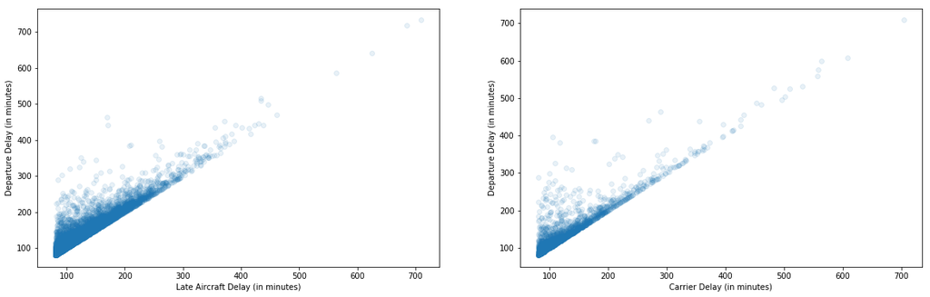

```python
# plotting scatter plot of positive late aircraft delay times against departure delay times
plt.figure(figsize = [20, 6])

plt.subplot(1, 2, 1)
plt.scatter(data = delayed_df.query('LateAircraftDelay > 80'), x = 'LateAircraftDelay', y = 'DepDelay', alpha = 0.1);
plt.xlabel('Late Aircraft Delay (in minutes)');
plt.ylabel('Departure Delay (in minutes)');

plt.subplot(1, 2, 2)
plt.scatter(data = delayed_df.query('CarrierDelay > 80'), x = 'CarrierDelay', y = 'DepDelay', alpha = 0.1);
plt.xlabel('Carrier Delay (in minutes)');
plt.ylabel('Departure Delay (in minutes)');
```

It looks like for delay times above 80 minutes, Late Aircraft delay and Carrier Delay a strong relationship with overal delay time -- i.e. contributes more to overall delay time.

```python
corr1 = delayed_df.query('CarrierDelay>80')['CarrierDelay'].corr(delayed_df['DepDelay'])
print("Correlation between Carrier delays above 80 minutes and Departure Delay: " + str(corr1))

corr2 = delayed_df.query('LateAircraftDelay>80')['LateAircraftDelay'].corr(delayed_df['DepDelay'])
print("Correlation between Late Aircraft delays above 80 minutes and Departure Delay " + str(corr2))
```

```
Correlation between Carrier delays above 80 minutes and Departure Delay: 0.914079343545
Correlation between Late Aircraft delays above 80 minutes and Departure Delay 0.92936539789
```

### What is the distribution of departure delay time for each airline carrier?

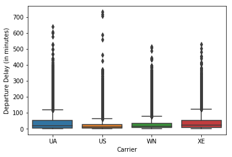

```python
# ploting a boxplot with Unique Carriers and DepDelay
sb.boxplot(data=delayed_df, x='UniqueCarrier', y='DepDelay');
plt.xlabel('Carrier');
plt.ylabel('Departure Delay (in minutes)');
```

There seems to be a lot of outliers, so let's try this boxplot again with deperature delay times less than 120.

```python
#querying DepDelay data with times less than 120 minutes
delay_lessthan120 = delayed_df.query('DepDelay < 120')
```

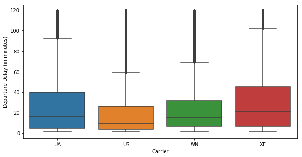

```python
#plotting a boxplot of UniqueCarrier vs DepDelay (less than 120 minutes)
plt.figure(figsize=[10, 5])
sb.boxplot(data=delay_lessthan120, x = 'UniqueCarrier', y = 'DepDelay');
plt.xlabel('Carrier');
plt.ylabel('Departure Delay (in minutes)');
```

Unique Carrier observations:

- The upper quartiles of departure XE (JSX Airline) and UA (United Airlines) have a lot of spread up their upper quartiles from around 20-100 minutes.
- US (US Airways) has the smallest IQR for departure delay times.

I want to look more closely at the distribution of the delay times for each carrier. Let's continue to focus on delay times less than 120 minutes.

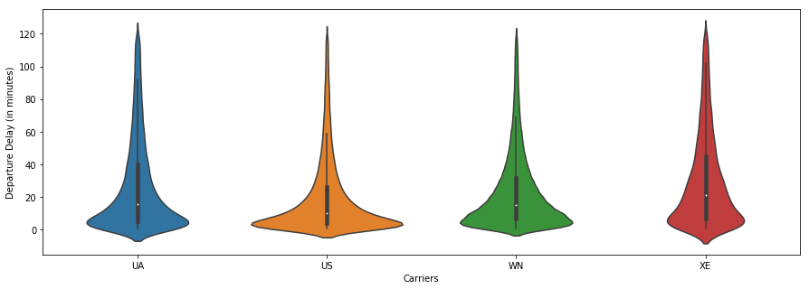

```python
#querying departure delay's less than 120 minutes
delay_lessthan120 = delayed_df.query('DepDelay < 120');
#plotting a violin plot of unique carriers vs departure delays (under 120 minutes)
plt.figure(figsize=[15, 5])
sb.violinplot(data=delay_lessthan120, x = 'UniqueCarrier', y = 'DepDelay');
plt.xlabel('Carriers');
plt.ylabel('Departure Delay (in minutes)');
```

US (US Airways) definitely has the highest concentration of departure delay times at its peak, which looks to be around 3 minutes. XE (JSX Airline) has the smoothest spread of deparature delay times compared to the other three airlines.

### What is the distribution of departure delay time for origin airports?

```python
# querying top 15 origin airports
top_origins = list(delayed_df.Origin.value_counts().head(15).index);
delay_top_origins = delayed_df.query('Origin == @top_origins')

#querying bottom 15 origin airports
bottom_origins = list(delayed_df.Origin.value_counts().tail(15).index);
delay_bottom_origins = delayed_df.query('Origin == @bottom_origins');
```

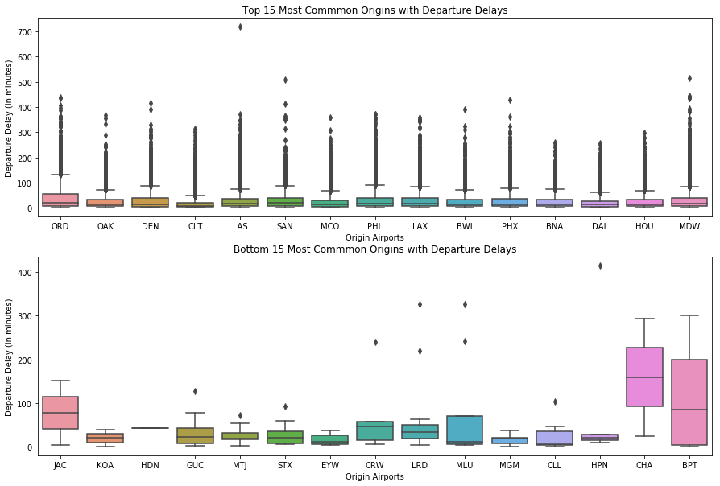

```python
# ploting a boxplot with top 15 Origins and DepDelay
plt.figure(figsize=[15,10])
plt.subplot(2, 1, 1)
sb.boxplot(data=delay_top_origins, x='Origin', y='DepDelay');
plt.xlabel('Origin Airports');
plt.ylabel('Departure Delay (in minutes)');
plt.title('Top 15 Most Commmon Origins with Departure Delays')

# plotting a boxplot with bottom 15 Origins and DepDelay
plt.subplot(2, 1, 2)
sb.boxplot(data=delay_bottom_origins, x='Origin', y='DepDelay');
plt.xlabel('Origin Airports');
plt.ylabel('Departure Delay (in minutes)');
plt.title('Bottom 15 Most Commmon Origins with Departure Delays');
```

The most common origin airports have significantly more outlier times, than the less common origin airports. Their IQR is also consistently below 120 minutes.

### What is the distribution of departure delay time for destination airports?

```python
# querying top 15 Destination airports
top_dests = list(delayed_df.Dest.value_counts().head(15).index);
delay_top_dests = delayed_df.query('Dest == @top_dests')

# querying botoom 25 Destination airports
bottom_dests = list(delayed_df.Dest.value_counts().tail(15).index);
delay_bottom_dests = delayed_df.query('Dest == @bottom_dests')
```

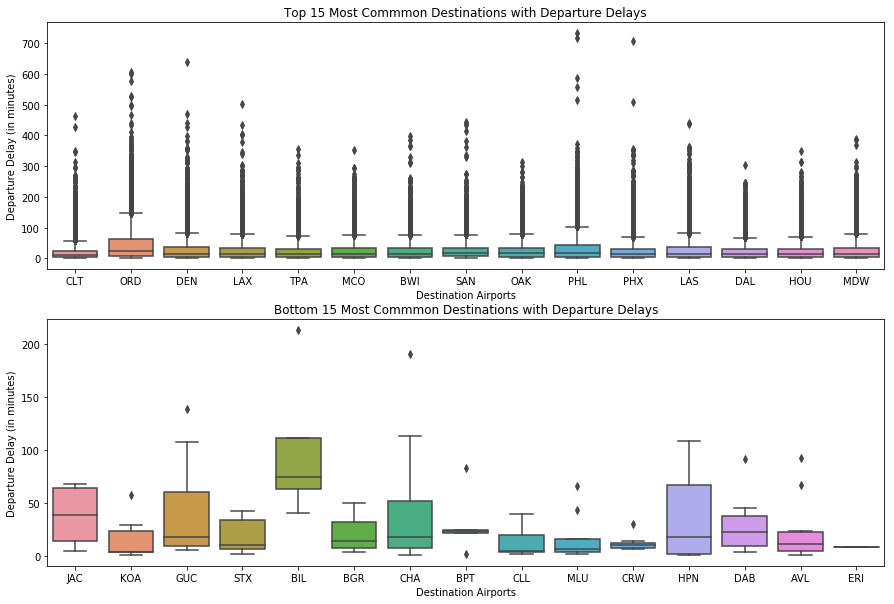

```python
# ploting a boxplot with top 15 Destinations and DepDelay
plt.figure(figsize=[15,10])
plt.subplot(2, 1, 1)
sb.boxplot(data=delay_top_dests, x='Dest', y='DepDelay');
plt.xlabel('Destination Airports');
plt.ylabel('Departure Delay (in minutes)');
plt.title('Top 15 Most Commmon Destinations with Departure Delays')

# plotting a boxplot with bottom 15 Destinations and DepDelay
plt.subplot(2, 1, 2)
sb.boxplot(data=delay_bottom_dests, x='Dest', y='DepDelay');
plt.xlabel('Destination Airports');
plt.ylabel('Departure Delay (in minutes)');
plt.title('Bottom 15 Most Commmon Destinations with Departure Delays');
```

I have similar observations about destination airports that I do for origin airports:

The most common destination airports have significantly more outlier times, than the less common origin airports. Their IQR is also consistently below 120 minutes (with the exception of 1 destination).

### What is the distribution of departure delay time for each day of the week?

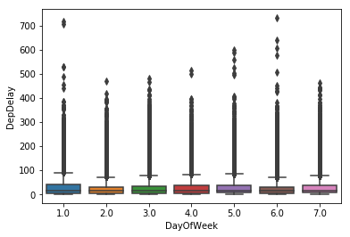

```python
# plotting a boxplot with Unique Carriers and DepDelay
sb.boxplot(data=delayed_df, x='DayOfWeek', y='DepDelay');
```

It looks like the majority of the data is below 100 minutes. Let's try this again with smaller departure delays.

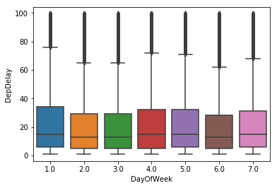

```python
#keeping delaytimes less than 100
delay_lessthan100 = delayed_df.query('DepDelay < 100');
sb.boxplot(data=delay_lessthan100, x='DayOfWeek', y='DepDelay');
```

It looks like there is no relationship between the day of the week and the delay time. It even looks like all the delay times are distributed the same from day to day.

One thing, I will do is look to see if there is any other relationships with day of the week.

### What is the distribution of carrier delays for each day of the week?

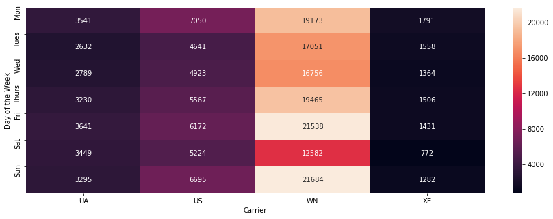

```python
# heatmap for days of the week and unique carrier
counts = delayed_df.groupby(['DayOfWeek', 'UniqueCarrier']).size()
counts = counts.reset_index(name = 'count')
counts = counts.pivot(index='DayOfWeek', columns='UniqueCarrier', values='count')

plt.figure(figsize=[15, 5])
sb.heatmap(counts, annot=True, fmt='d');
plt.yticks([0, 1, 2, 3, 4, 5, 6], ['Mon', 'Tues', 'Wed', 'Thurs', 'Fri', 'Sat', 'Sun']);
plt.xlabel('Carrier');
plt.ylabel('Day of the Week');
```

Observations between Unique Carriers and Days of the Week: Most common day of the week for delayed flights by carrier:

- UA: Fri - Mon
- US: Mon, Fri, Sun
- WN: Fri & Sun
- XE: Mon

Monday and Friday seem to have the highest frequency of delayed flights by carrier.

### What is the distribution of origin airport delays for each day of the week?

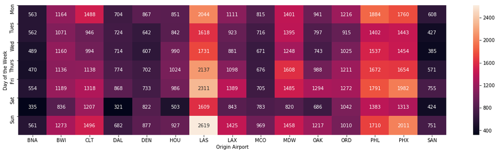

```python
# correlation plot for days of the week and top origins
counts = delay_top_origins.groupby(['DayOfWeek', 'Origin']).size()
counts = counts.reset_index(name = 'count')
counts = counts.pivot(index='DayOfWeek', columns='Origin', values='count')

plt.figure(figsize=[20, 5])
sb.heatmap(counts, annot=True, fmt='d');
plt.yticks([0, 1, 2, 3, 4, 5, 6], ['Mon', 'Tues', 'Wed', 'Thurs', 'Fri', 'Sat', 'Sun']);
plt.xlabel('Origin Airport');
plt.ylabel('Day of the Week');
```

- LAS, PHL, PHX, MDW has the highest frequency of delayed flights
- LAS airport has a high frequency of delayed flights on Fridays & Sundays

Otherwise it's difficult to see any general relationships between the origin airport and day of the week.

### What is the distribution of destination airport delays for each day of the week?

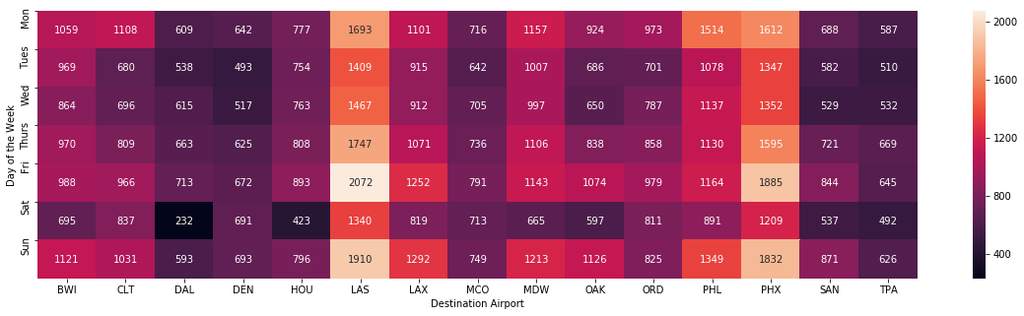

```python
# correlation plot for days of the week and top destinations
counts = delay_top_dests.groupby(['DayOfWeek', 'Dest']).size()
counts = counts.reset_index(name = 'count')
counts = counts.pivot(index='DayOfWeek', columns='Dest', values='count')

plt.figure(figsize=[20, 5])
sb.heatmap(counts, annot=True, fmt='d');
plt.yticks([0, 1, 2, 3, 4, 5, 6], ['Mon', 'Tues', 'Wed', 'Thurs', 'Fri', 'Sat', 'Sun']);
plt.xlabel('Destination Airport');
plt.ylabel('Day of the Week');
```

- LAS, PHL, and PHX have the highest frequency of delayed flights
- LAS airport has a high frequency of delayed flights on Fridays & Sundays

Otherwise it's difficult to see any general relationships between the destination airport and day of the week.

### What is the distribution of delay types for each day of the week?

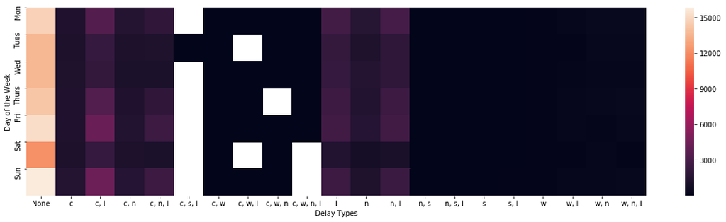

```python
#plot heatmap with delay types vs day of the week

counts = delayed_df.groupby(['DayOfWeek', 'delay']).size()
counts = counts.reset_index(name = 'count')
counts = counts.pivot(index='DayOfWeek', columns='delay', values='count')

plt.figure(figsize=[20, 5])
sb.heatmap(counts);
plt.yticks([0, 1, 2, 3, 4, 5, 6], ['Mon', 'Tues', 'Wed', 'Thurs', 'Fri', 'Sat', 'Sun']);
plt.xlabel('Delay Types');
plt.ylabel('Day of the Week');
```

This is a poor visualization, let's just look at the frequency of the 3 top delay types (Late aircraft, Carrier, and NAS) by day of the week.

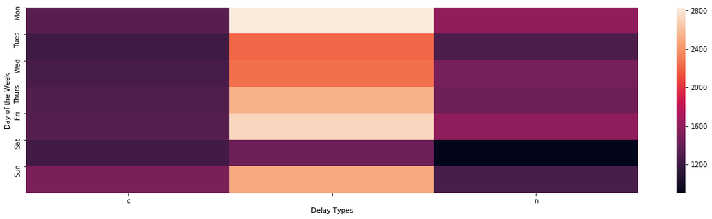

```python
#subset the delay type column to only look at delay of one type
top3_delays = delayed_df[delayed_df.delay.isin(['l', 'c', 'n'])]

#plot heatmap with top 3 delay types vs day of the week
counts = top3_delays.groupby(['DayOfWeek', 'delay']).size()
counts = counts.reset_index(name = 'count')
counts = counts.pivot(index='DayOfWeek', columns='delay', values='count')

plt.figure(figsize=[20, 5])
sb.heatmap(counts);
plt.yticks([0, 1, 2, 3, 4, 5, 6], ['Mon', 'Tues', 'Wed', 'Thurs', 'Fri', 'Sat', 'Sun']);
plt.xlabel('Delay Types');
plt.ylabel('Day of the Week');
```

The most common day(s) of the week for each delay type to occur:

- Carrier Delay: Sunday
- Late Aircraft Delay: Monday and Friday
- NAS Delay: Monday and Friday

### Talk about some of the relationships you observed in this part of the investigation. How did the feature(s) of interest vary with other features in the dataset?

> Delay Types:
> - There is a strong (75%) correlation between the departure delay time and late aircraft delay time. Additionally, when you look at departure delays over 80 minutes, there is a very strong relationship (above 90%) between departure delay time and two delay types (carrier delay & late aircraft delay).

> Carriers:
> - the upper quartiles of departure XE (JSX Airline) and UA (United Airlines) have a lot of spread up their upper quartiles from around 20-100 minutes.
> - US (US Airways) has the smallest IQR for departure delay times.

> Origin & Destination Airports:
> - The most common airports have significantly more outlier delay times, than the less common airports.

> Day of the Week:
> - The day of the week didn't actually seem to have any impact on general delay times.

### Did you observe any interesting relationships between the other features (not the main feature(s) of interest)?

I decided to look at days of the week vs other features since there wasn't a strong relationship between day of the week vs general delay time.

> Day of Week vs Carrier
> - Monday and Friday seem to have the highest frequency of delayed flights by carrier.

> Day of Week vs Origin/Destination
> - LAS, PHL, and PHX have the highest frequency of delayed flights
> - LAS airport has a high frequency of delayed flights on Fridays & Sundays

> Day of Week vs Delay Type
> - The most common day(s) of the week for each delay type to occur:
>   - Carrier Delay: Sunday
>   - Late Aircraft Delay: Monday and Friday
>   - NAS Delay: Monday and Friday

## Multivariate Exploration

Average delay time for each type by day of the week X-day of the week Y- average departure delay Color = delay type

groupby each delay type, then by day of the week. calculate average delay time

I would like to look at the average departure delay for a variety of scenarios:

- by day of the week & delay type
- by day of the week & unique carrier
- by day of the week & origin
- by day of the week & destination
- by delay type & unique carrier

I would like to start by looking at the Average Departure Delay by Day of the Week vs Delay Type. I don't want to look at all combinations of delay types though, just the main 5.

Although we had seen that departure delay didn't vary from day to day, we did start to see some a higher frequency of certain delay types for certain days of the week. I would like to see if there is additional relationship when we though in average departure delay time too.

### What is the average delay time for each delay type throughout the week?

```python
# putting rows from the dataframe that just have 'l', 'c', 'n', 's', 'w'
# as the delay type (no multiple delay reasons)
pure_delays = delayed_df[delayed_df.delay.isin(['l', 'c', 'n', 's', 'w'])]
```

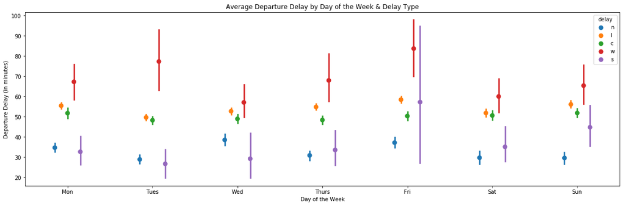

```python
# plotting a pointplot for Average Departure Delay by Day of the Week & Delay Type
fig = plt.figure(figsize = [20,6]);
ax = sb.pointplot(data = pure_delays, x = 'DayOfWeek', y = 'DepDelay', hue = 'delay',
                  linestyles = '', dodge = 0.3);
plt.title('Average Departure Delay by Day of the Week & Delay Type');
plt.xticks([0, 1, 2, 3, 4, 5, 6], ['Mon', 'Tues', 'Wed', 'Thurs', 'Fri', 'Sat', 'Sun']);
plt.xlabel('Day of the Week');
plt.ylabel('Departure Delay (in minutes)');
```

Observations:

- Although security delay usually tends to have a small departure delay on average, it jumps up to almonst double its average delay time on Fridays with a much larger margin of error.
- Although weather delay usually tends to have a long departure delay on average, Wednesdays, Saturdays & Sundays, delays are shorter than the rest of the week on average. **It's important to remember that weather and security delays have very low frequencies compared to the rest of the delay types, so these observations may not be very reliable.**

Otherwise, it looks like NAS delays are consistently 30-40 minutes on average from day to day and Late Aircraft & Carrier delays are consistently 50-60 minutes on average from day to day.

Let's not take a look at Average Departure Delay by Day of the Week & Carrier. We saw that Mondays & Fridays seemed to have the highest frequency of delays when the data was segmented by carrier. Also US (US Airways) has the smallest IQR for departure delay times.

I would like to see how this relationship translates when we look at all three variables together.

### What is the average delay time for each carrier throughout the week?

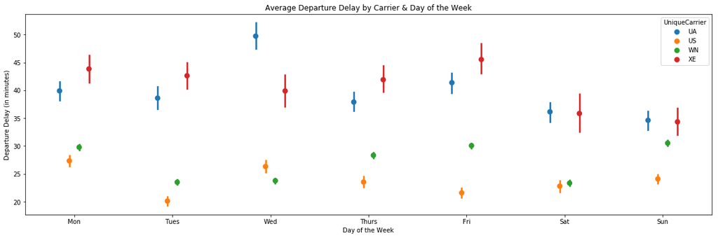

```python
fig = plt.figure(figsize = [20,6]);
ax = sb.pointplot(data = delayed_df, x = 'DayOfWeek', y = 'DepDelay', hue = 'UniqueCarrier',
                  linestyles = '', dodge = 0.3);
plt.title('Average Departure Delay by Carrier & Day of the Week');
plt.xticks([0, 1, 2, 3, 4, 5, 6], ['Mon', 'Tues', 'Wed', 'Thurs', 'Fri', 'Sat', 'Sun']);
plt.xlabel('Day of the Week');
plt.ylabel('Departure Delay (in minutes)');
```

Observations:

- XE and UA tend to have higher average delay times (35-50 minutes), but are their lowest on Saturday and Sunday.
- WN and US tend to have lower average delay times (20-32 minutes)
- UA has its longest average delay time on Wednesday.

Let's take a look at Average Departure Delay by Day of the Week & Origin airport and Average Departure Delay by Day of the Week & Destination airport.

There weren't very strong relationships across the board for day of the week vs origin/destination. What we say was that LAS, PHL, and PHX have the highest frequency of delayed flights. Also LAS airport has a high frequency of delayed flights on Fridays & Sundays.

Then for delay times, the most common airports have significantly more outlier times, but their IQRs were consistently below 120 minutes.

I'd like to see how all three of these relationships come together (first for origin airports, then for destination airports).

### What is the average delay time for top origin airports & destination airports throughout the week?

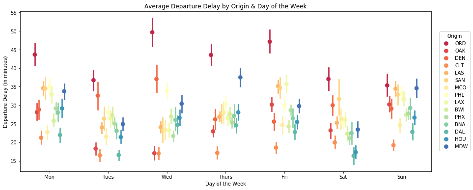

```python
fig = plt.figure(figsize = [15,6]);
ax = sb.pointplot(data = delay_top_origins, x = 'DayOfWeek', y = 'DepDelay', hue = 'Origin',
                  linestyles = '', dodge = 0.5, palette = 'Spectral', n_colors = 15);
plt.title('Average Departure Delay by Origin & Day of the Week');
plt.xticks([0, 1, 2, 3, 4, 5, 6], ['Mon', 'Tues', 'Wed', 'Thurs', 'Fri', 'Sat', 'Sun']);
plt.xlabel('Day of the Week');
plt.ylabel('Departure Delay (in minutes)');
plt.legend(title = 'Origin', bbox_to_anchor=(1.1, .5), loc='right');
```

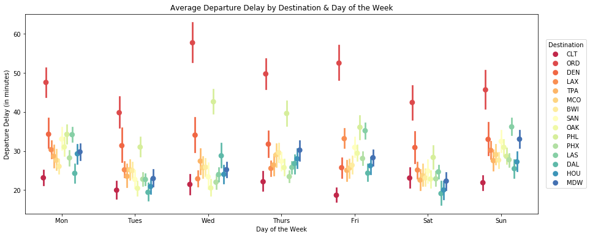

```python
fig = plt.figure(figsize = [15,6]);
ax = sb.pointplot(data = delay_top_dests, x = 'DayOfWeek', y = 'DepDelay', hue = 'Dest',
                  linestyles = '', dodge = 0.5, palette = 'Spectral', n_colors = 15);
plt.title('Average Departure Delay by Destination & Day of the Week');
plt.xticks([0, 1, 2, 3, 4, 5, 6], ['Mon', 'Tues', 'Wed', 'Thurs', 'Fri', 'Sat', 'Sun']);
plt.xlabel('Day of the Week');
plt.ylabel('Departure Delay (in minutes)');
plt.legend(title = 'Destination', bbox_to_anchor=(1.1, .5), loc='right');
```

Observations:

- Although the delay time does vary, ORD has the longest average delay time over any other airport for every day of the week.
- Without ORD as an origin or destination, the average delay times fall within the same range from day to day, 15 - 40 minutes.

The last plot I'd like to look at is Average Departure Delay by Delay Type & Carrier.

I'm interested in looking at this because when I looked at the distribution of delay times by carrier, two of the airlines (XE and UA) had much more spread in their upper quartiles and and US had the smallest IQR. I want to see how if these relationships can be attributed to delay type.

### Is there a difference in how long each delay type lasts for each carrier?¶

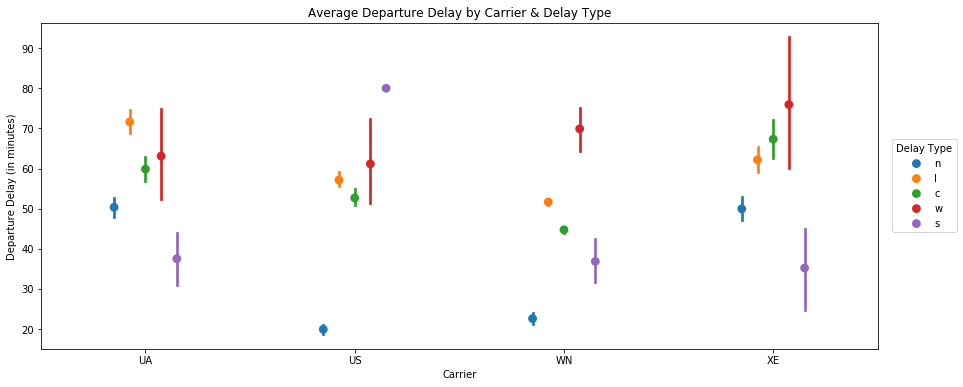

```python
fig = plt.figure(figsize = [15,6]);
ax = sb.pointplot(data = pure_delays, x = 'UniqueCarrier', y = 'DepDelay', hue = 'delay',
                  linestyles = '', dodge = 0.3);
plt.title('Average Departure Delay by Carrier & Delay Type');
plt.xlabel('Carrier');
plt.ylabel('Departure Delay (in minutes)');
plt.legend(title = 'Delay Type', bbox_to_anchor=(1.1, .5), loc='right');
```

Observations:

- When looking at the data segmented by delay type, it's hard to tell that there was much difference in the distribution of delay times by carrier only.
- US and WN have the lowest NAS delays on average (around 20-25 minutes)
- Weather delays have a large confidence intervals across all carriers.
- US has the longest security delays on average at about 80 minutes.

### Talk about some of the relationships you observed in this part of the investigation. Were there features that strengthened each other in terms of looking at your feature(s) of interest?

> Average Departure Delay by Day of the Week & Carrier
> - UA (United Airlines) has its longest average delay time on Wednesday.

> Average Departure Delay by Carrier & Delay Types
> - US (US Airways) and WN (Southwest Airlines) have the lowest NAS delays on average (around 20-25 minutes).
> - US has the longest security delays on average at about 80 minutes.

> Average Departure Delay by Day of the Week & Origin/Destination
> - Although the delay time does vary, ORD has the longest average delay time over any other airport for every day of the week.
> - Without ORD as an origin or destination, the average delay times fall within the same range from day to day, 15 - 40 minutes.

### Were there any interesting or surprising interactions between features?

> I was surprised that there weren't any stronger relationships between departure delay vs day of the week after segmenting by several features. There weren't very many strong patterns when looking at multi-variables. There were more bivariate relationships within every point plot.

## Conclusions

At the beginning of this project, I had started with about 2.5 million flights spanning from 1987 to 2008. After wrangling the data, dealing with missing values, and only keeping data with flight delays, I was left with about 200K flights. Although only a fraction of what I started with, it still felt like an exceptable amount of data to do some analysis. *Note: after wrangling there were only 4 remaining airline carriers.*

Throughout my exploration, the main feature of interest has been departure delay time. Here is what I found:

> Features with high frequency of departures delays:
> - Late Aircraft delays, Carrier Delay, and NAS (National Aviation System) delays
> - WN (Southwest Airlines) had the most delayed flights out of all 4 carriers
> - The top 10 origins and destinations for delayed flights were: LAS, PHX, PHL, MDW, CLT, BWI, ORD, LAX, OAK, & HOU
> - Most of the days of the week had about the same frequency except for Saturday (1/3 less than the day with the highest frequency).

> Features that contribute to long departure delays (above 40 minutes):
> - Weather delays: From day to day, the average delay times are around 60-90 minutes.
> - Late Aircraft & Carrier delays:
>   - The correlation between Late Aircraft delays above 80 minutes and Departure Delay was 0.93. The correlation between Carrier delays above 80 minutes and Departure Delay was 0.91.
>   - From day to day, the average delay times are around 50-60 minutes.
> - XE & UA (carriers):
>   - In general, JSX Airline (XE) & United Airlines (UA) have a lot of spread in their upper quartiles for departures delay times, spreading up to 100 minutes.
>   - From day to day, the average delay times are around 35 - 50 minutes (with the exception of Saturday and Sunday).
> - Common Airports:
>   - The most common airports have significantly more high outlier delay times than the less common airports.
>   - ORD (Chicago O'Hare International Airport) has the longest average delay time over any other airport for every day of the week, 35-60 minutes.

> Interesting finds:
> - US Airways (US) and Southwest Airlines (WN) have the lowest NAS delays on average (around 20-25 minutes)
> - US Airways (US) have the longest security delays on average at about 80 minutes.